# 2_known_prep_analysis

Ajay Prakash Nair

2024-11-14

# Requirements

```r
requirements=c("summarytools", "pROC", "glmnetUtils", "dplyr", "car", "effects", "gridExtra", "grid", "MASS","e1071", "mgcv", "caret", "gridExtra", "effects", "nnet", "ggplot2", "reshape2", "MASS")

for (req in requirements){
  if (!require(req, character.only = TRUE)){
      install.packages(req)
  }
}
```

```
## lattice theme set by effectsTheme()
## See ?effectsTheme for details.
```

# Analysis Description

This analysis focuses on building and evaluating predictive models using logistic regression, Linear Discriminant Analysis and Naive Bayes for the dataset. The dataset comprises training and testing data that was splitted in the previous stage.The objective is to assess the predictive performance of the models and evaluate their ability to classify outcomes accurately.

# Loading data

```r
train_data <- read.csv("./training/training.csv")
cat("Training data dimensions:", dim(train_data), "\n")
```

```
## Training data dimensions: 3725 19
```

```r
test_data <- read.csv("./testing/test.csv")
cat("Testing data dimensions:", dim(test_data), "\n")
```

```
## Testing data dimensions: 1595 19
```

# Logistic Regression

The logistic regression analysis involves two main stages: model building and evaluation. In the model-building stage, logistic regression models are trained using the training dataset. Two models are considered: one with all variables and another with only relevant variables.

```r
# Relevel reference level as "Draw"
train_data$FTR <- relevel(factor(train_data$FTR), ref = "Draw")

# Fit initial model
multinom_model <- multinom(FTR ~ HTHG + HTAG + HTR + HS + AS + HST + AST + HF + AF + HC + AC + HY + AY + HR + AR, data = train_data)
summary(multinom_model)
```

```
## Call:
## multinom(formula = FTR ~ HTHG + HTAG + HTR + HS + AS + HST +
##     AST + HF + AF + HC + AC + HY + AY + HR + AR, data = train_data)
##
## Coefficients:
##          (Intercept)      HTHG       HTAG       HTRD        HTRH           HS
## Away Win  -0.5261998 -0.994776  0.8065173 -0.3193110 -0.05843956 -0.003525015
## Home Win   0.5732350  1.397862 -1.4075465 -0.5817378 -0.72982566 -0.055984068
##                    AS        HST        AST          HF           AF
## Away Win -0.072107715 -0.1043841  0.4579813 0.015800842 -0.005040651
## Home Win  0.003680031  0.3956115 -0.2045125 0.002226963  0.006070424
##                    HC          AC          HY          AY         HR         AR
## Away Win -0.006831452 -0.03951353  0.01875469 -0.01995771  0.3967883 -0.7096283
## Home Win -0.075987123  0.02263266 -0.02012436 -0.02838101 -0.6249663  0.1126642
##
## Std. Errors:
##          (Intercept)      HTHG      HTAG      HTRD      HTRH         HS
## Away Win   0.4459203 0.2428066 0.2213551 0.2806954 0.5236313 0.01581094
## Home Win   0.4563700 0.2520255 0.2653880 0.3156198 0.5694151 0.01456103
##                  AS        HST        AST         HF         AF         HC
## Away Win 0.01799642 0.03329498 0.03637173 0.01305396 0.01290380 0.02064345
## Home Win 0.01603638 0.02989454 0.03378954 0.01207468 0.01185651 0.01866928
##                  AC         HY         AY        HR        AR
## Away Win 0.02418262 0.03760170 0.03636733 0.1336658 0.1544153
## Home Win 0.02192084 0.03499389 0.03333425 0.1553709 0.1164986
##
## Residual Deviance: 5218.169
## AIC: 5286.169
```

### Key Findings:

- **Half-Time Goals**:
  - **HTHG** (Half-Time Home Team Goals): Strongly affects the likelihood of a **Home Win** (1.397862).
  - **HTAG** (Half-Time Away Team Goals): Increases the likelihood of an **Away Win** (0.8065173).
- **Shots on Target**:
  - **HST** (Home Shots on Target): Significant for predicting **Home Wins**, with more shots on target decreasing the likelihood of an **Away Win**.
  - **AST** (Away Shots on Target): Significant for predicting **Away Wins**, with more shots on target increasing the likelihood of an **Away Win**.
- **Red Cards**:
  - **HR** (Home Red Cards): Has a significant positive effect on **Away Wins**. More home red cards increase the likelihood of an **Away Win**.
  - **AR** (Away Red Cards): Has a minor effect on **Home Wins**, suggesting it has a slight influence on match outcomes.
- **Other Match Statistics**:
  - Most other match statistics, such as **Fouls**, **Yellow Cards**, and **Corners**, show smaller or no significant effects on match outcomes.

### Checking Multicollinearity

```r
vif(multinom_model)
```

```
##           GVIF Df GVIF^(1/(2*Df))
## HTHG 10.548341  1        3.247821
## HTAG 16.856784  1        4.105701
## HTR  50.617501  2        2.667320
## HS   20.340710  1        4.510068
## AS   19.300999  1        4.393290
## HST   9.721619  1        3.117951
## AST  12.518941  1        3.538212
## HF   15.890753  1        3.986321
## AF   15.258216  1        3.906177
## HC    7.571968  1        2.751721
## AC    6.249663  1        2.499933
## HY    5.519487  1        2.349359
## AY    5.666709  1        2.380485
## HR    1.347426  1        1.160787
## AR    1.257799  1        1.121517
```

The HTR (Half-Time Result) variable has a high VIF of 50.61. Also, HS and AS have a VIF of more than 18 , suggesting significant multicollinearity with other predictors in the model. So, lets check mullticollinearity by removing it.

```r
multinom_model.clean <- update(multinom_model, .~.-HTR -HS -AS)
vif(multinom_model.clean)
```

```
##      HTHG      HTAG       HST       AST        HF        AF        HC        AC
##  1.913563  2.391196  6.459970  7.432431 15.786120 15.167632  6.437169  5.423926
##        HY        AY        HR        AR
##  5.471716  5.627507  1.330529  1.247287
```

After removing HTR, HS, and AS from the model, the VIF results show improved multicollinearity for the remaining variables except AF and HF. So, removing AF and HF too.

```r
multinom_model.clean <- update(multinom_model.clean, .~.-HF -AF)
vif(multinom_model.clean)
```

```
##     HTHG     HTAG      HST      AST       HC       AC       HY       AY
## 1.898005 2.374506 6.433298 7.420064 6.341693 5.394368 4.775410 5.081157
##       HR       AR
## 1.331183 1.243808
```

Let’s see the summary of the updated cleaned model.

```r
summary(multinom_model.clean)
```

```
## Call:
## multinom(formula = FTR ~ HTHG + HTAG + HST + AST + HC + AC +
##     HY + AY + HR + AR, data = train_data)
##
## Coefficients:
##          (Intercept)      HTHG       HTAG        HST        AST           HC
## Away Win  -1.0182436 -1.002401  0.9522976 -0.1121584  0.3697319 -0.001819238
## Home Win  -0.1927857  1.209832 -1.1029157  0.3288100 -0.2000109 -0.103869886
##                   AC          HY          AY         HR          AR
## Away Win -0.07314713  0.03803309 -0.01711317  0.3533381 -0.69990871
## Home Win  0.03110637 -0.01368263 -0.02401639 -0.6148532  0.07746643
##
## Std. Errors:
##          (Intercept)       HTHG       HTAG       HST        AST         HC
## Away Win   0.2268307 0.10346574 0.08252021 0.0269497 0.02791306 0.01875457
## Home Win   0.2097158 0.07816671 0.09539772 0.0236528 0.02749535 0.01727511
##                  AC         HY         AY        HR        AR
## Away Win 0.02236437 0.03473334 0.03421626 0.1315258 0.1531253
## Home Win 0.02027278 0.03242081 0.03156189 0.1536959 0.1149123
##
## Residual Deviance: 5265.557
## AIC: 5309.557
```

Compare the AIC for the two models.

```r
AIC(multinom_model, multinom_model.clean) %>% arrange(AIC)
```

```
##                      df      AIC
## multinom_model       34 5286.169
## multinom_model.clean 22 5309.557
```

The cleaned model appears to have a higher AIC thus up to now we prefer the full initial model. Lower AIC indicates a better fit, so multinom_model is the preferred model between the two in terms of fit. multinom_model.clean has fewer predictors (22 degrees of freedom vs 34) but results in a higher AIC, suggesting it may have sacrificed model complexity without improving fit sufficiently.

## Interaction Terms

We are adding the following interaction terms : **HTHG × HTAG** (Home half-time goals × Away half-time goals) **HST × AST** (Home shots on target × Away shots on target) **HR × AR** (Home red cards × Away red cards) **HY × AY** (Home yellow cards × Away yellow cards)

```r
multinom_model.inter <- update(multinom_model,
                         . ~ . + HTHG:HTAG + HST:AST + HR:AR + HY:AY)
summary(multinom_model.inter)
```

```
## Call:
## multinom(formula = FTR ~ HTHG + HTAG + HTR + HS + AS + HST +
##     AST + HF + AF + HC + AC + HY + AY + HR + AR + HTHG:HTAG +
##     HST:AST + HR:AR + HY:AY, data = train_data)
##
## Coefficients:
##          (Intercept)      HTHG       HTAG       HTRD       HTRH          HS
## Away Win  -0.4550234 -1.468889  0.7665055 -0.3039863  0.3847365 -0.00154808
## Home Win   0.4789109  1.344377 -1.4342683 -0.6064362 -0.7095188 -0.05567144
##                    AS         HST        AST          HF           AF
## Away Win -0.071488965 -0.04636583  0.5189475 0.015620458 -0.004934631
## Home Win  0.003748917  0.44024613 -0.1462704 0.002313665  0.006792046
##                   HC          AC          HY          AY         HR         AR
## Away Win -0.01022844 -0.03978349 -0.10211317 -0.13091063  0.3524777 -0.7791584
## Home Win -0.07688408  0.02245535 -0.05555767 -0.05917601 -0.6326265  0.1023049
##           HTHG:HTAG     HST:AST      HR:AR      HY:AY
## Away Win 0.33193902 -0.01451856 0.29353383 0.04318950
## Home Win 0.06634039 -0.01283019 0.02493121 0.01222783
##
## Std. Errors:
##          (Intercept)      HTHG      HTAG      HTRD      HTRH         HS
## Away Win   0.5115780 0.3376126 0.2223007 0.2815476 0.5653343 0.01584374
## Home Win   0.5357986 0.2535360 0.3250592 0.3564194 0.5864293 0.01459743
##                  AS        HST        AST         HF         AF         HC
## Away Win 0.01801908 0.05956655 0.05923784 0.01307614 0.01295519 0.02071533
## Home Win 0.01604522 0.04774958 0.06128633 0.01208350 0.01189273 0.01869811
##                  AC         HY         AY        HR        AR HTHG:HTAG
## Away Win 0.02427265 0.07329409 0.06868607 0.1473885 0.1732168  0.163886
## Home Win 0.02192106 0.06794923 0.06149228 0.1733944 0.1248175  0.152391
##             HST:AST     HR:AR      HY:AY
## Away Win 0.01132596 0.3189311 0.02221576
## Home Win 0.01084670 0.3177398 0.02065079
##
## Residual Deviance: 5206.905
## AIC: 5290.905
```

HST:AST, HY:AY appear to be not so much significant. So removing it.

```r
multinom_model.inter <- update(multinom_model.inter, . ~ . -HST:AST -HY:AY)
summary(multinom_model.inter)
```

```
## Call:
## multinom(formula = FTR ~ HTHG + HTAG + HTR + HS + AS + HST +
##     AST + HF + AF + HC + AC + HY + AY + HR + AR + HTHG:HTAG +
##     HR:AR, data = train_data)
##
## Coefficients:
##          (Intercept)      HTHG       HTAG       HTRD       HTRH           HS
## Away Win  -0.4726063 -1.448221  0.7593684 -0.3148251  0.3572209 -0.002816962
## Home Win   0.6019907  1.351741 -1.4320217 -0.6035887 -0.7088235 -0.056064942
##                    AS        HST        AST         HF           AF
## Away Win -0.072412959 -0.1061744  0.4591112 0.01510014 -0.005884017
## Home Win  0.003582261  0.3957745 -0.2048746 0.00209950  0.006102817
##                    HC          AC          HY          AY         HR         AR
## Away Win -0.008031454 -0.03921611  0.01964942 -0.01743057  0.3410269 -0.7767359
## Home Win -0.076066747  0.02281890 -0.02041186 -0.02784992 -0.6337295  0.1060136
##           HTHG:HTAG      HR:AR
## Away Win 0.31757147 0.30549787
## Home Win 0.05168617 0.02173836
##
## Std. Errors:
##          (Intercept)      HTHG      HTAG      HTRD      HTRH         HS
## Away Win   0.4468481 0.3377646 0.2224337 0.2815000 0.5656057 0.01582263
## Home Win   0.4934004 0.2538529 0.3247850 0.3562447 0.5863337 0.01456365
##                  AS        HST        AST         HF         AF         HC
## Away Win 0.01799740 0.03341416 0.03639093 0.01306255 0.01293005 0.02067941
## Home Win 0.01603877 0.02992794 0.03379420 0.01207845 0.01186371 0.01866943
##                  AC         HY         AY        HR        AR HTHG:HTAG
## Away Win 0.02422076 0.03763744 0.03641036 0.1468169 0.1732499 0.1636407
## Home Win 0.02191772 0.03500020 0.03335245 0.1734623 0.1245172 0.1521651
##              HR:AR
## Away Win 0.3194733
## Home Win 0.3178426
##
## Residual Deviance: 5212.942
## AIC: 5288.942
```

Let’s check the AIC

```r
AIC(multinom_model, multinom_model.clean, multinom_model.inter) %>% arrange(AIC)
```

```
##                      df      AIC
## multinom_model       34 5286.169
## multinom_model.inter 38 5288.942
## multinom_model.clean 22 5309.557
```

By looking at the AIC the best model remain the initial full model. Now let’s try adding interaction terms to the clean model. Now let’s add the following interactions:

**HTHG × HTAG** (Home half-time goals × Away half-time goals) **HST × AST** (Home shots on target × Away shots on target) **HR × AR** (Home red cards × Away red cards) **HY × AY** (Home yellow cards × Away yellow cards)

```r
multinom_model.clean.inter <- update(multinom_model.clean,
                         . ~ . + HTHG:HTAG + HST:AST + HR:AR + HY:AY)
summary(multinom_model.clean.inter)
```

```
## Call:
## multinom(formula = FTR ~ HTHG + HTAG + HST + AST + HC + AC +
##     HY + AY + HR + AR + HTHG:HTAG + HST:AST + HR:AR + HY:AY,
##     data = train_data)
##
## Coefficients:
##          (Intercept)      HTHG       HTAG         HST        AST           HC
## Away Win  -0.9564284 -1.023947  0.9594442 -0.04802357  0.4322630 -0.003991415
## Home Win  -0.3060603  1.258763 -0.9871152  0.37335301 -0.1431863 -0.104747730
##                   AC          HY          AY         HR         AR   HTHG:HTAG
## Away Win -0.07350931 -0.08531366 -0.13208572  0.3107047 -0.7717649  0.01236692
## Home Win  0.03066261 -0.05601528 -0.06242889 -0.6168729  0.0657249 -0.11358470
##              HST:AST      HR:AR      HY:AY
## Away Win -0.01486384 0.27987193 0.04405163
## Home Win -0.01263486 0.01508025 0.01482142
##
## Std. Errors:
##          (Intercept)       HTHG       HTAG        HST        AST         HC
## Away Win   0.3351441 0.14804250 0.09719169 0.05553818 0.05390136 0.01879907
## Home Win   0.3003106 0.09351704 0.13448099 0.04404970 0.05799975 0.01731295
##                  AC         HY         AY        HR        AR HTHG:HTAG
## Away Win 0.02243267 0.07114776 0.06691888 0.1452205 0.1715599 0.1160645
## Home Win 0.02029007 0.06642421 0.06003259 0.1718049 0.1234448 0.1092169
##            HST:AST     HR:AR      HY:AY
## Away Win 0.0111915 0.3133095 0.02197507
## Home Win 0.0108064 0.3146583 0.02055530
##
## Residual Deviance: 5256.781
## AIC: 5316.781
```

```r
AIC(multinom_model, multinom_model.inter, multinom_model.clean, multinom_model.clean.inter) %>% arrange(AIC)
```

```
##                            df      AIC
## multinom_model             34 5286.169
## multinom_model.inter       38 5288.942
## multinom_model.clean       22 5309.557
## multinom_model.clean.inter 30 5316.781
```

And it seems like that the full model is just slightly better with respect to the full model with interaction terms.

## Model Interpretation

We have decided to interpret the model multinom_model based on its lower AIC value (5286.169), which suggests that it provides the best balance between fit and complexity.

To begin the interpretation, we recall the model’s summary:

```r
summary(multinom_model)
```

```
## Call:
## multinom(formula = FTR ~ HTHG + HTAG + HTR + HS + AS + HST +
##     AST + HF + AF + HC + AC + HY + AY + HR + AR, data = train_data)
##
## Coefficients:
##          (Intercept)      HTHG       HTAG       HTRD        HTRH           HS
## Away Win  -0.5261998 -0.994776  0.8065173 -0.3193110 -0.05843956 -0.003525015
## Home Win   0.5732350  1.397862 -1.4075465 -0.5817378 -0.72982566 -0.055984068
##                    AS        HST        AST          HF           AF
## Away Win -0.072107715 -0.1043841  0.4579813 0.015800842 -0.005040651
## Home Win  0.003680031  0.3956115 -0.2045125 0.002226963  0.006070424
##                    HC          AC          HY          AY         HR         AR
## Away Win -0.006831452 -0.03951353  0.01875469 -0.01995771  0.3967883 -0.7096283
## Home Win -0.075987123  0.02263266 -0.02012436 -0.02838101 -0.6249663  0.1126642
##
## Std. Errors:
##          (Intercept)      HTHG      HTAG      HTRD      HTRH         HS
## Away Win   0.4459203 0.2428066 0.2213551 0.2806954 0.5236313 0.01581094
## Home Win   0.4563700 0.2520255 0.2653880 0.3156198 0.5694151 0.01456103
##                  AS        HST        AST         HF         AF         HC
## Away Win 0.01799642 0.03329498 0.03637173 0.01305396 0.01290380 0.02064345
## Home Win 0.01603638 0.02989454 0.03378954 0.01207468 0.01185651 0.01866928
##                  AC         HY         AY        HR        AR
## Away Win 0.02418262 0.03760170 0.03636733 0.1336658 0.1544153
## Home Win 0.02192084 0.03499389 0.03333425 0.1553709 0.1164986
##
## Residual Deviance: 5218.169
## AIC: 5286.169
```

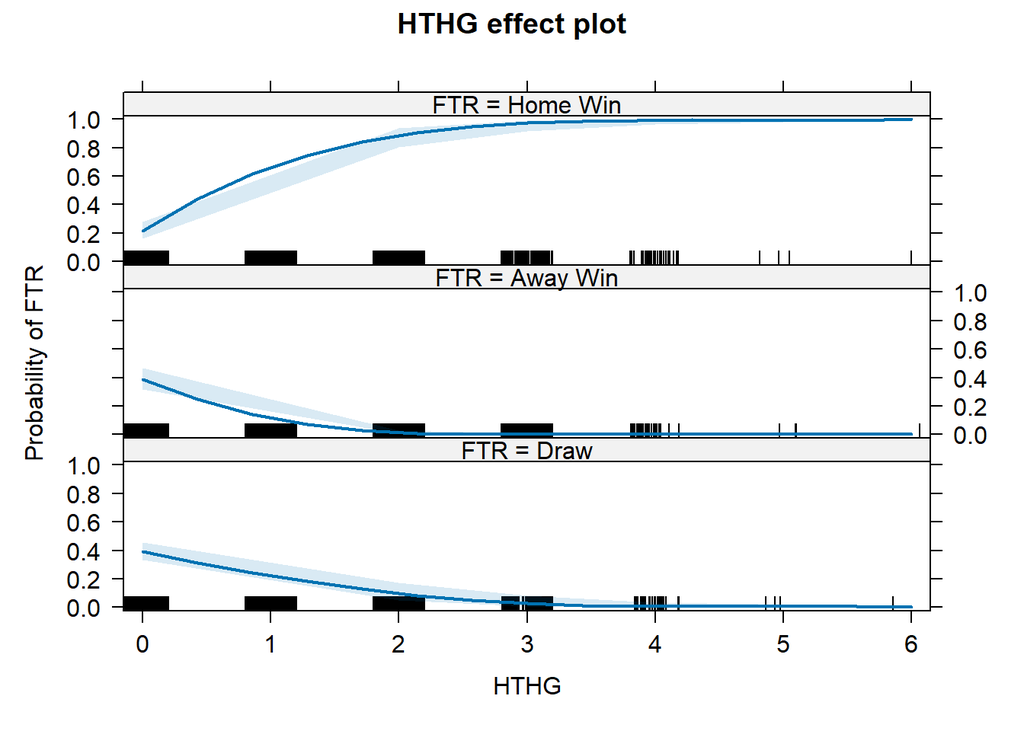

```r
# Plot for HTHG (Home Team Home Goals)
a <- effect("HTHG", multinom_model)
plot(a, rescale.axis = FALSE, ylab = "Probability of FTR")
```

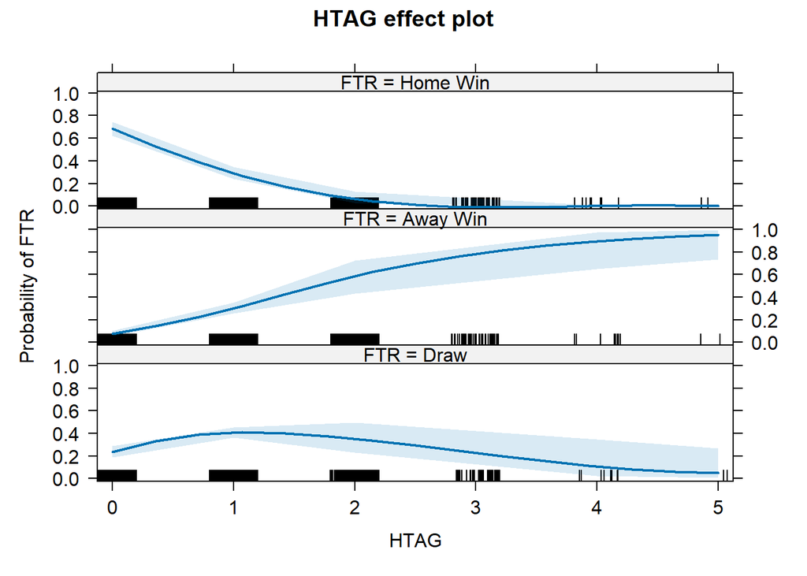

```r
# Plot for HTAG (Home Team Away Goals)
b <- effect("HTAG", multinom_model)
plot(b, rescale.axis = FALSE, ylab = "Probability of FTR")
```

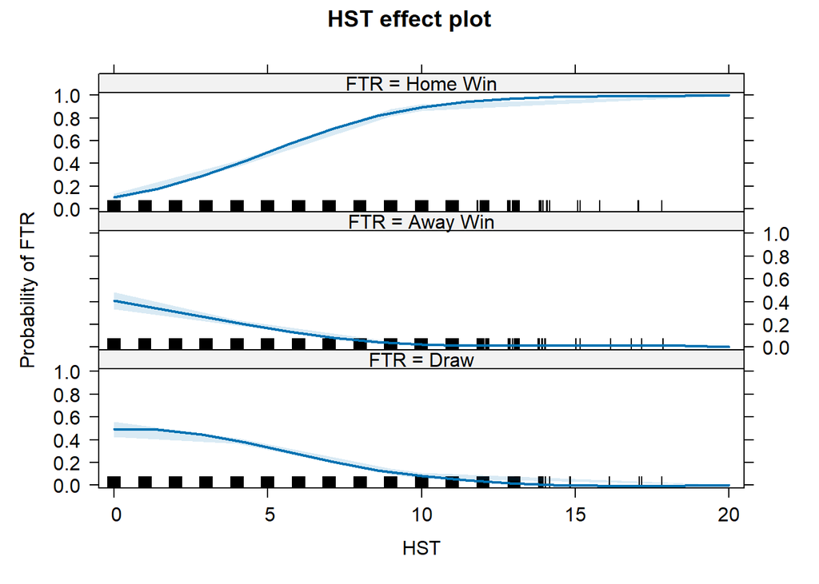

```r
# Plot for HST (Home Team Shots)
c <- effect("HST", multinom_model)
plot(c, rescale.axis = FALSE, ylab = "Probability of FTR")
```

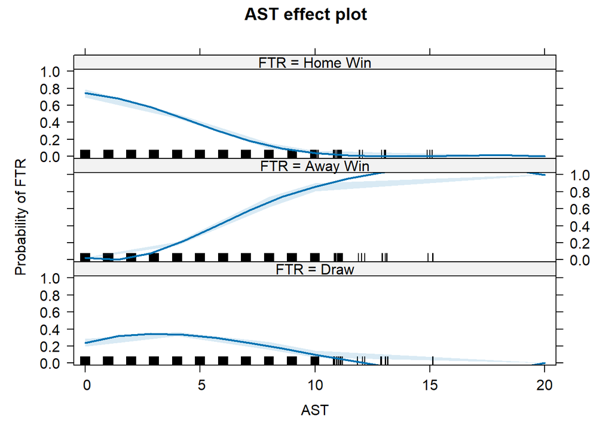

```r
# Plot for AST (Away Team Shots)
d <- effect("AST", multinom_model)
plot(d, rescale.axis = FALSE, ylab = "Probability of FTR")
```

As we can see, if Half Time Home Team Goals (HTHG) are greater than 3, the probability of the home team winning is 1; if Half Time Away Goals (HTAG) are greater than 2, the probability of the away team winning is more than 0.5; if the Home Team Shots on Target (HST) are greater than 10, the probability of the home team winning is high; and if the Away Team Shots on Target (AST) are greater than 10, the probability of the away team winning is high.

## Model Comparison

Let’s compare all the models done so far in terms of prediction power to be able to compare them with other types of models:

```r
test_data <- read.csv("testing/test.csv")
```

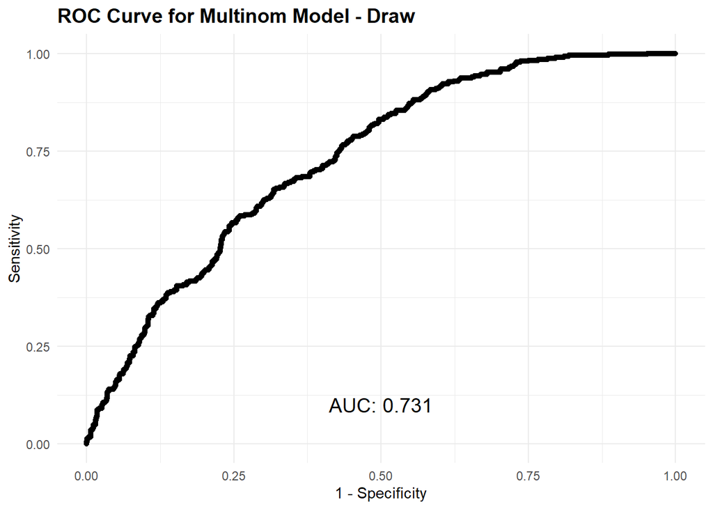

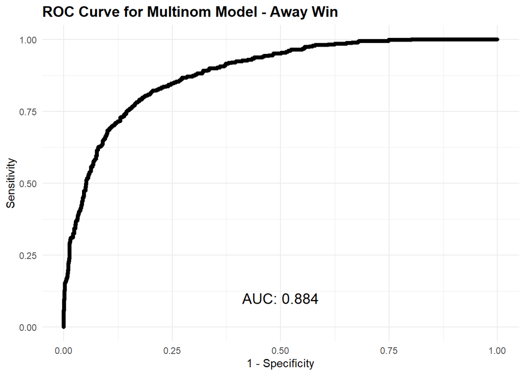

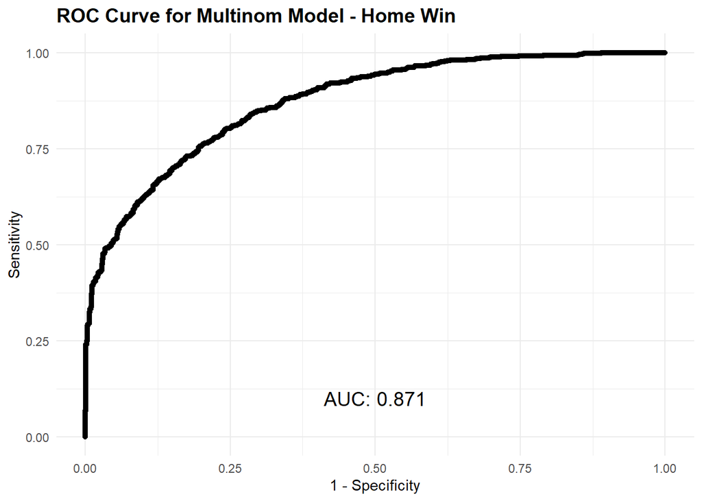

```r
plot_roc <- function(test_data, prob_matrix, model_name) {
  roc_list <- lapply(1:ncol(prob_matrix), function(i) {
    roc(test_data$FTR == colnames(prob_matrix)[i], prob_matrix[, i])
  })

  auc_values <- sapply(roc_list, function(r) auc(r))
  class_names <- colnames(prob_matrix)

  for (i in 1:length(roc_list)) {
    class_name <- class_names[i]
    class_roc <- roc_list[[i]]

    roc_data <- data.frame(
      Specificity = 1 - class_roc$specificities,
      Sensitivity = class_roc$sensitivities
    )

    p <- ggplot(data = roc_data, aes(x = Specificity, y = Sensitivity)) +
      geom_line(size = 1, color = "black") +
      geom_point(color = "black") +
      labs(
        title = paste("ROC Curve for", model_name, "-", class_name),
        x = "1 - Specificity",
        y = "Sensitivity"
      ) +
      theme_minimal() +
      theme(plot.title = element_text(size = 14, face = "bold"),
            plot.subtitle = element_text(size = 12)) +
      annotate("text", x = 0.5, y = 0.1,
               label = paste("AUC:", round(auc_values[i], 3)),
               size = 5, hjust = 0.5)

    print(p)
  }
}


# Compute probabilities for each model
prob_multinom_model <- predict(multinom_model, test_data, type = "prob")
prob_multinom_model.inter <- predict(multinom_model.inter, test_data, type = "prob")
prob_multinom_model.clean <- predict(multinom_model.clean, test_data, type = "prob")
prob_multinom_model.clean.inter <- predict(multinom_model.clean.inter, test_data, type = "prob")

# Plot ROC curves for each model
plot_roc(test_data, prob_multinom_model, "Multinom Model")
```

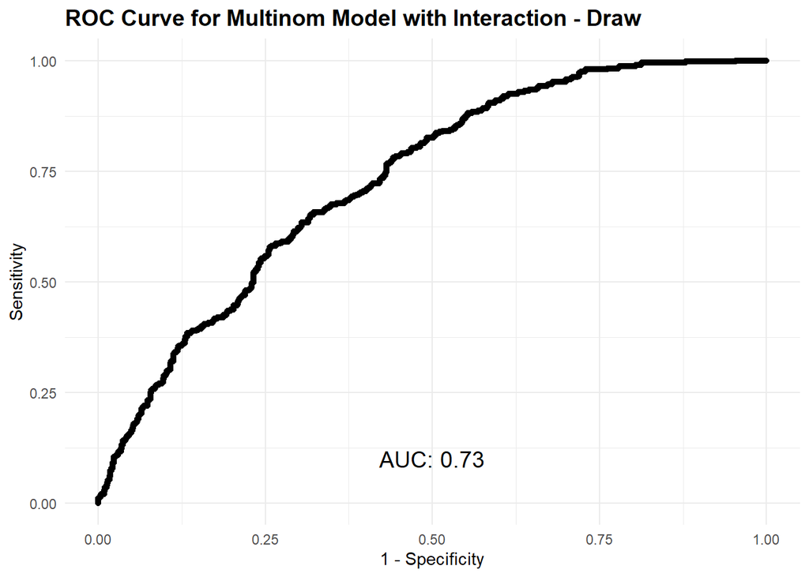

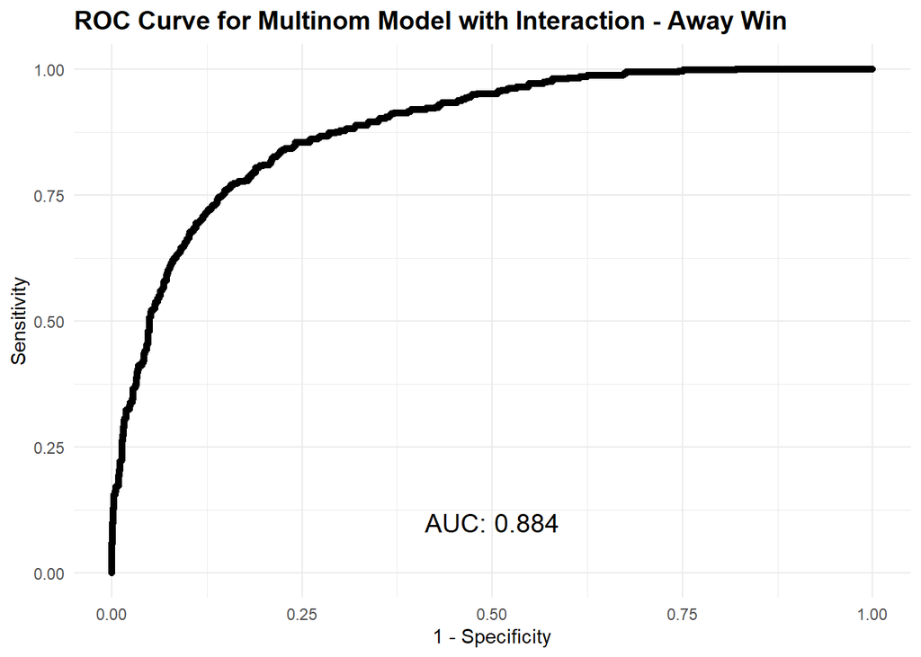

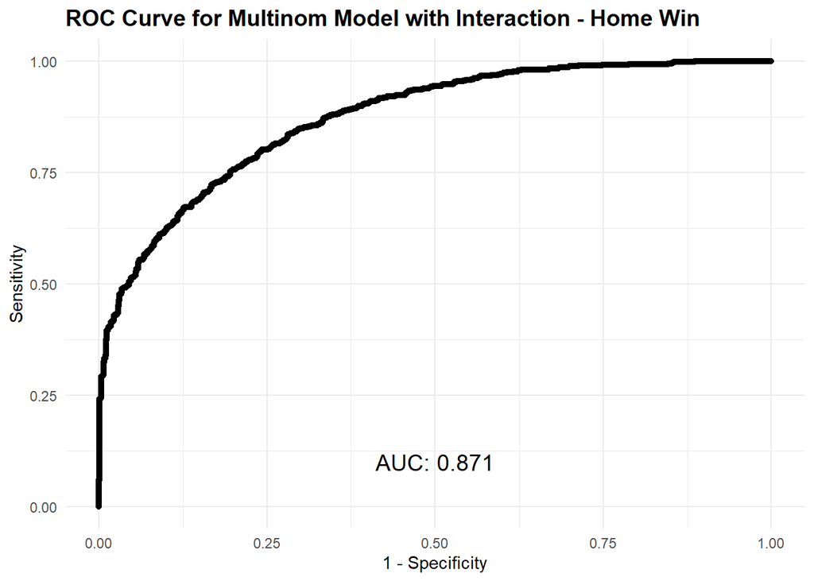

```r
plot_roc(test_data, prob_multinom_model.inter, "Multinom Model with Interaction")
```

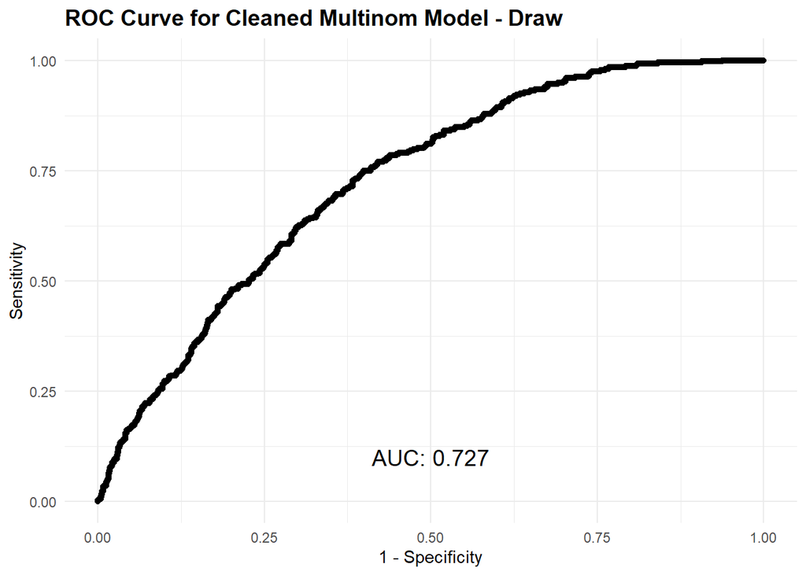

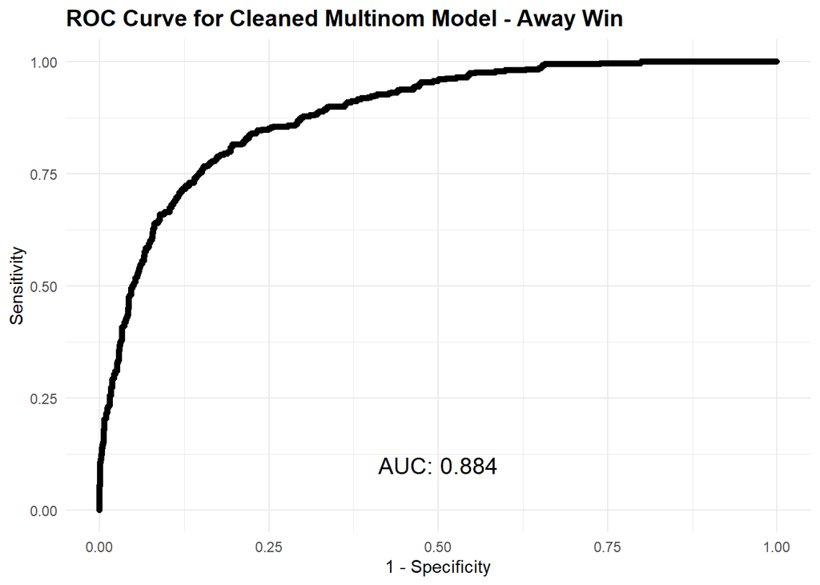

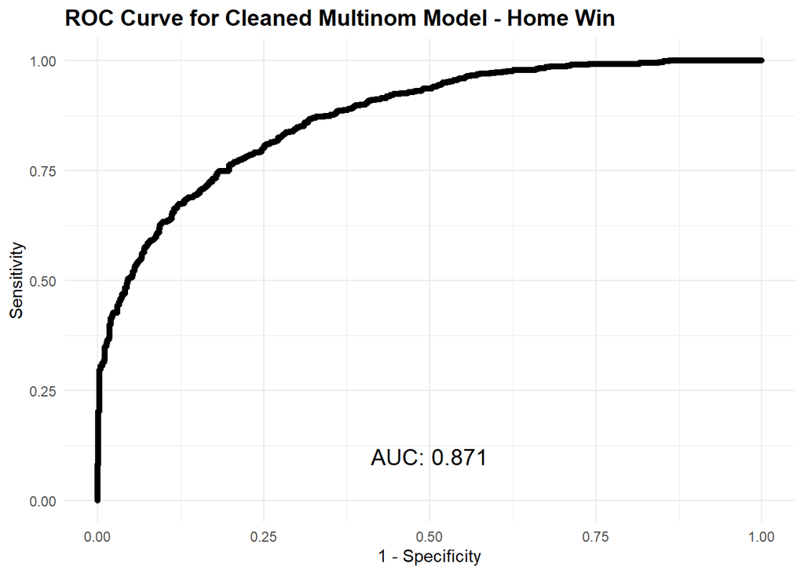

```r
plot_roc(test_data, prob_multinom_model.clean, "Cleaned Multinom Model")
```

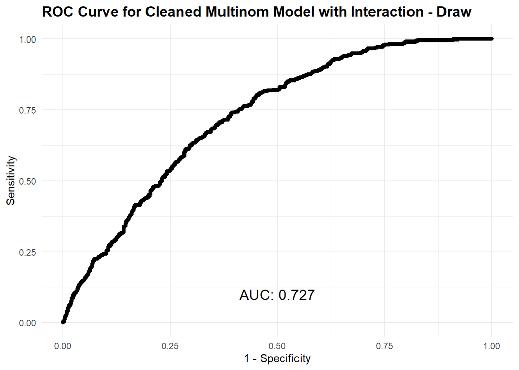

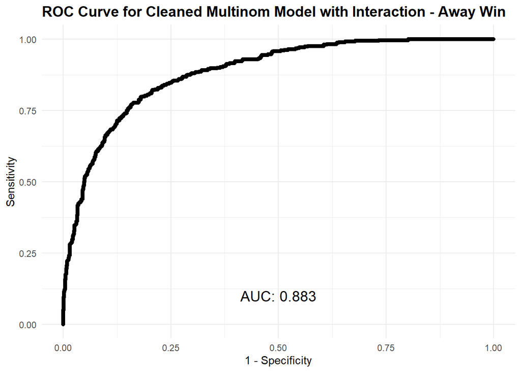

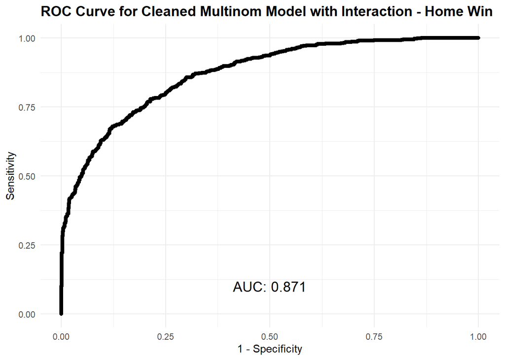

```r
plot_roc(test_data, prob_multinom_model.clean.inter, "Cleaned Multinom Model with Interaction")
```

By the plots we can see that the Area Under the Curve (AUC) computed by the ROC curves gives almost the same results.

Now we extract from each roc object the best threshold in order to use it during predictions.

```r
# Compute individual ROC curves for each class
roc_list_full <- lapply(1:ncol(prob_multinom_model), function(i) {
  roc(test_data$FTR == colnames(prob_multinom_model)[i], prob_multinom_model[, i])
})
roc_list_full_inter <- lapply(1:ncol(prob_multinom_model.inter), function(i) {
  roc(test_data$FTR == colnames(prob_multinom_model.inter)[i], prob_multinom_model.inter[, i])
})
roc_list_clean <- lapply(1:ncol(prob_multinom_model.clean), function(i) {
  roc(test_data$FTR == colnames(prob_multinom_model.clean)[i], prob_multinom_model.clean[, i])
})
roc_list_clean_inter <- lapply(1:ncol(prob_multinom_model.clean.inter), function(i) {
  roc(test_data$FTR == colnames(prob_multinom_model.clean.inter)[i], prob_multinom_model.clean.inter[, i])
})
# Extract metrics for each ROC curve
extract_metrics <- function(roc_list) {
  lapply(roc_list, function(r) {
    # Get the best coordinates (threshold, specificity, sensitivity, accuracy)
    coords(r, x = "best", ret = c("threshold", "specificity", "sensitivity", "accuracy"))
  })
}

# Extract metrics for each model
roc_metrics_full <- extract_metrics(roc_list_full)
roc_metrics_full_inter <- extract_metrics(roc_list_full_inter)
roc_metrics_clean <- extract_metrics(roc_list_clean)
roc_metrics_clean_inter <- extract_metrics(roc_list_clean_inter)
```

Rename the single row for each dataframe and concatenate all in a single one.

```r
# Combine metrics for each model into a data frame
combine_metrics <- function(roc_metrics_list) {
  metrics <- do.call(rbind, roc_metrics_list)
  rownames(metrics) <- colnames(prob_multinom_model)
  return(metrics)
}

# Combine metrics for all models
roc_metrics_full <- combine_metrics(roc_metrics_full)
roc_metrics_full_inter <- combine_metrics(roc_metrics_full_inter)
roc_metrics_clean <- combine_metrics(roc_metrics_clean)
roc_metrics_clean_inter <- combine_metrics(roc_metrics_clean_inter)
```

Now we make a comparisons result:

```r
# Compute average metrics (across classes) for each model
average_metrics <- function(metrics) {
  colMeans(metrics, na.rm = TRUE)
}

# Calculate average metrics for each model
average_metrics_full <- average_metrics(roc_metrics_full)
average_metrics_full_inter <- average_metrics(roc_metrics_full_inter)
average_metrics_clean <- average_metrics(roc_metrics_clean)
average_metrics_clean_inter <- average_metrics(roc_metrics_clean_inter)


# Combine into a single data frame with model names and metrics
comparison_df <- data.frame(
  Model = rep(c("Full Model", "Full Interaction Model", "Cleaned Model", "Cleaned Interaction Model"), each = 3),
  Class = rep(c("Away Win", "Draw", "Home Win"), times = 4),
  Accuracy = c(average_metrics_full["accuracy"],
               average_metrics_full_inter["accuracy"],
               average_metrics_clean["accuracy"],
               average_metrics_clean_inter["accuracy"]),
  Sensitivity = c(average_metrics_full["sensitivity"],
                  average_metrics_full_inter["sensitivity"],
                  average_metrics_clean["sensitivity"],
                  average_metrics_clean_inter["sensitivity"]),
  Specificity = c(average_metrics_full["specificity"],
                  average_metrics_full_inter["specificity"],
                  average_metrics_clean["specificity"],
                  average_metrics_clean_inter["specificity"])
)

# Print the comparison data frame
print(comparison_df)
```

```
##                        Model    Class  Accuracy Sensitivity Specificity
## 1                 Full Model Away Win 0.7299896   0.7885189   0.7148773
## 2                 Full Model     Draw 0.7289446   0.8058413   0.6985173
## 3                 Full Model Home Win 0.7433647   0.7705527   0.7412823
## 4     Full Interaction Model Away Win 0.7356322   0.7924588   0.7180400
## 5     Full Interaction Model     Draw 0.7299896   0.7885189   0.7148773
## 6     Full Interaction Model Home Win 0.7289446   0.8058413   0.6985173
## 7              Cleaned Model Away Win 0.7433647   0.7705527   0.7412823
## 8              Cleaned Model     Draw 0.7356322   0.7924588   0.7180400
## 9              Cleaned Model Home Win 0.7299896   0.7885189   0.7148773
## 10 Cleaned Interaction Model Away Win 0.7289446   0.8058413   0.6985173
## 11 Cleaned Interaction Model     Draw 0.7433647   0.7705527   0.7412823
## 12 Cleaned Interaction Model Home Win 0.7356322   0.7924588   0.7180400
```

For **Away Win**, the model with the highest accuracy is the **Cleaned Model** (74.34%), which also has the highest specificity (74.13%), while the **Cleaned Interaction Model** achieves the highest sensitivity (80.58%).

For **Draw**, the model with the highest accuracy and specificity is the **Cleaned Interaction Model** (74.34% and 74.13%, respectively), whereas the **Full Model** provides the highest sensitivity (80.58%).

We can see that the response is unbalanced.

### Confusion Matrixes

Let’s have a quick look on the confusion matrix for the four model that we have specified.

```r
test_data$FTR <- factor(test_data$FTR, levels = c("Away Win", "Draw", "Home Win"))

# Predict class labels for each model using the best thresholds
pred_multinom_model <- factor(predict(multinom_model, test_data, type = "class"), levels = c("Away Win", "Draw", "Home Win"))
pred_multinom_model.inter <- factor(predict(multinom_model.inter, test_data, type = "class"), levels = c("Away Win", "Draw", "Home Win"))
pred_multinom_model.clean <- factor(predict(multinom_model.clean, test_data, type = "class"), levels = c("Away Win", "Draw", "Home Win"))
pred_multinom_model.clean.inter <- factor(predict(multinom_model.clean.inter, test_data, type = "class"), levels = c("Away Win", "Draw", "Home Win"))

# Generate confusion matrices for each model
conf_matrix_multinom_model <- confusionMatrix(pred_multinom_model, test_data$FTR)
conf_matrix_multinom_model.inter <- confusionMatrix(pred_multinom_model.inter, test_data$FTR)
conf_matrix_multinom_model.clean <- confusionMatrix(pred_multinom_model.clean, test_data$FTR)
conf_matrix_multinom_model.clean.inter <- confusionMatrix(pred_multinom_model.clean.inter, test_data$FTR)
```

1. Full Model

```r
print(conf_matrix_multinom_model)
```

```
## Confusion Matrix and Statistics
##
##           Reference
## Prediction Away Win Draw Home Win
##   Away Win      307   88       47
##   Draw           75  137       75
##   Home Win       65  171      630
##
## Overall Statistics
##
##                Accuracy : 0.6734
##                  95% CI : (0.6497, 0.6963)
##     No Information Rate : 0.4715
##     P-Value [Acc > NIR] : < 2.2e-16
##
##                   Kappa : 0.4746
##
##  Mcnemar's Test P-Value : 5.397e-09
##
## Statistics by Class:
##
##                      Class: Away Win Class: Draw Class: Home Win
## Sensitivity                   0.6868     0.34596          0.8378
## Specificity                   0.8824     0.87490          0.7200
## Pos Pred Value                0.6946     0.47735          0.7275
## Neg Pred Value                0.8786     0.80199          0.8326
## Prevalence                    0.2803     0.24828          0.4715
## Detection Rate                0.1925     0.08589          0.3950
## Detection Prevalence          0.2771     0.17994          0.5429
## Balanced Accuracy             0.7846     0.61043          0.7789
```

2. Full Interaction Model

```r
print(conf_matrix_multinom_model.inter)
```

```
## Confusion Matrix and Statistics
##
##           Reference
## Prediction Away Win Draw Home Win
##   Away Win      311   89       50
##   Draw           73  135       73
##   Home Win       63  172      629
##
## Overall Statistics
##
##                Accuracy : 0.674
##                  95% CI : (0.6504, 0.697)
##     No Information Rate : 0.4715
##     P-Value [Acc > NIR] : < 2.2e-16
##
##                   Kappa : 0.4757
##
##  Mcnemar's Test P-Value : 2.367e-09
##
## Statistics by Class:
##
##                      Class: Away Win Class: Draw Class: Home Win
## Sensitivity                   0.6957     0.34091          0.8364
## Specificity                   0.8789     0.87823          0.7212
## Pos Pred Value                0.6911     0.48043          0.7280
## Neg Pred Value                0.8812     0.80137          0.8317
## Prevalence                    0.2803     0.24828          0.4715
## Detection Rate                0.1950     0.08464          0.3944
## Detection Prevalence          0.2821     0.17618          0.5417
## Balanced Accuracy             0.7873     0.60957          0.7788
```

3. Cleaned Model

```r
print(conf_matrix_multinom_model.clean)
```

```
## Confusion Matrix and Statistics
##
##           Reference
## Prediction Away Win Draw Home Win
##   Away Win      313   95       45
##   Draw           71  128       85
##   Home Win       63  173      622
##
## Overall Statistics
##
##                Accuracy : 0.6665
##                  95% CI : (0.6427, 0.6896)
##     No Information Rate : 0.4715
##     P-Value [Acc > NIR] : < 2.2e-16
##
##                   Kappa : 0.4643
##
##  Mcnemar's Test P-Value : 5.912e-08
##
## Statistics by Class:
##
##                      Class: Away Win Class: Draw Class: Home Win
## Sensitivity                   0.7002     0.32323          0.8271
## Specificity                   0.8780     0.86989          0.7200
## Pos Pred Value                0.6909     0.45070          0.7249
## Neg Pred Value                0.8827     0.79558          0.8236
## Prevalence                    0.2803     0.24828          0.4715
## Detection Rate                0.1962     0.08025          0.3900
## Detection Prevalence          0.2840     0.17806          0.5379
## Balanced Accuracy             0.7891     0.59656          0.7736
```

4. Cleaned Interaction Model

```r
print(conf_matrix_multinom_model.clean.inter)
```

```
## Confusion Matrix and Statistics
##
##           Reference
## Prediction Away Win Draw Home Win
##   Away Win      307   94       49
##   Draw           78  130       83
##   Home Win       62  172      620
##
## Overall Statistics
##
##                Accuracy : 0.6627
##                  95% CI : (0.6389, 0.6859)
##     No Information Rate : 0.4715
##     P-Value [Acc > NIR] : < 2.2e-16
##
##                   Kappa : 0.4588
##
##  Mcnemar's Test P-Value : 1.912e-07
##
## Statistics by Class:
##
##                      Class: Away Win Class: Draw Class: Home Win
## Sensitivity                   0.6868      0.3283          0.8245
## Specificity                   0.8754      0.8657          0.7224
## Pos Pred Value                0.6822      0.4467          0.7260
## Neg Pred Value                0.8777      0.7960          0.8219
## Prevalence                    0.2803      0.2483          0.4715
## Detection Rate                0.1925      0.0815          0.3887
## Detection Prevalence          0.2821      0.1824          0.5354
## Balanced Accuracy             0.7811      0.5970          0.7734
```

## Model Selection

### Stepwise Model

```r
full_model <- multinom(FTR ~ HTHG + HTAG + HTR + HS + AS + HST + AST + HF + AF + HC + AC + HY + AY + HR + AR, data = test_data)
stepwise_model <- stepAIC(full_model, direction = "both", trace = 0)
summary(stepwise_model)
```

```
## Call:
## multinom(formula = FTR ~ HTHG + HTAG + HTR + HST + AST + AF +
##     HC + AC + HY + AY, data = test_data)
##
## Coefficients:
##          (Intercept)      HTHG       HTAG       HTRD       HTRH       HST
## Draw      -0.8142961 0.6153863 -0.2408944  1.2265704  1.4446863 0.1717651
## Home Win   0.6253735 2.4761529 -2.3142740 -0.5002895 -0.8349139 0.4838921
##                 AST         AF           HC         AC          HY          AY
## Draw     -0.3609658 0.02747574 -0.006873052 0.05068697  0.08754128 -0.04378206
## Home Win -0.5152480 0.04485339 -0.085495010 0.07813693 -0.03940428 -0.13109019
##
## Std. Errors:
##          (Intercept)      HTHG      HTAG      HTRD      HTRH        HST
## Draw       0.5996849 0.3399248 0.3047032 0.4071765 0.7429285 0.04179539
## Home Win   0.7365434 0.4985807 0.5017098 0.5667831 1.0683555 0.04477524
##                 AST         AF         HC         AC         HY         AY
## Draw     0.04398623 0.01981186 0.02868614 0.03400855 0.05394899 0.05675959
## Home Win 0.04798867 0.02113210 0.03163352 0.03635762 0.05867286 0.06055801
##
## Residual Deviance: 2291.505
## AIC: 2339.505
```

```r
# Calculate AIC for each model
aic_full <- AIC(multinom_model)
aic_full_inter <- AIC(multinom_model.inter)
aic_clean <- AIC(multinom_model.clean)
aic_clean_inter <- AIC(multinom_model.clean.inter)
aic_stepwise <- AIC(stepwise_model)

aic_results <- data.frame(
  Model = c("Full Model", "Interaction Full Model", "Cleaned Model", "Interaction Cleaned Model", "Stepwise Model"),
  AIC = c(aic_full, aic_full_inter, aic_clean, aic_clean_inter, aic_stepwise)
)

aic_results_sorted <- aic_results %>% arrange(AIC)

print(aic_results_sorted)
```

```
##                       Model      AIC
## 1            Stepwise Model 2339.505
## 2                Full Model 5286.169
## 3    Interaction Full Model 5288.942
## 4             Cleaned Model 5309.557
## 5 Interaction Cleaned Model 5316.781
```

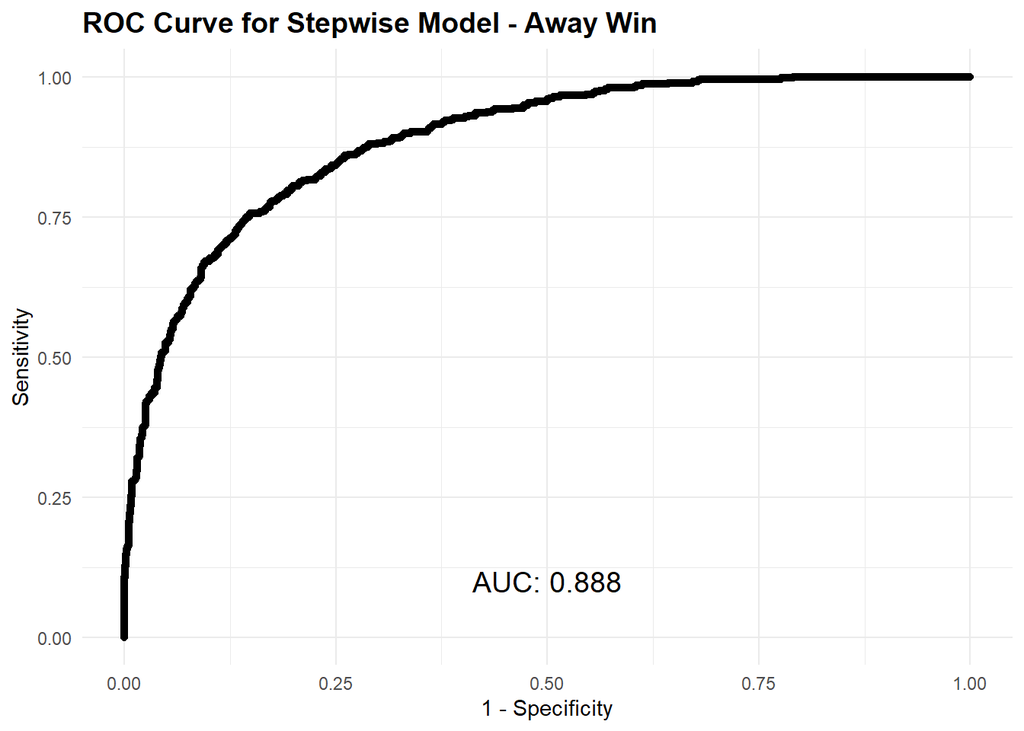

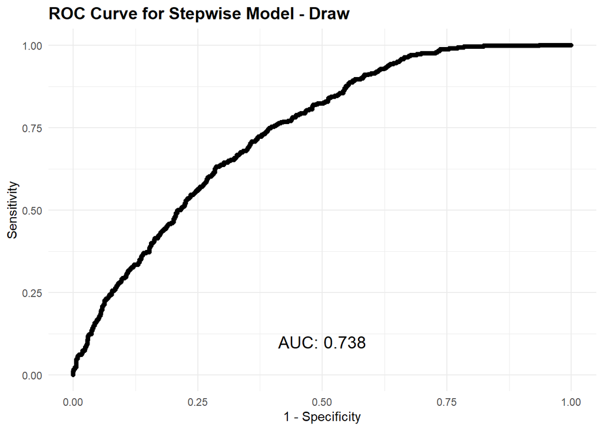

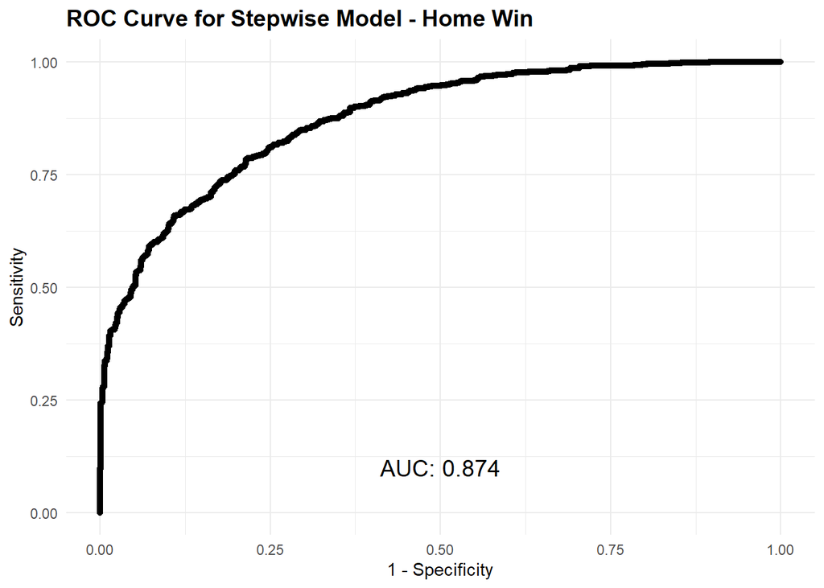

```r
prob_stepwise_model <- predict(stepwise_model, test_data, type = "prob")

plot_roc(test_data, prob_stepwise_model, "Stepwise Model")
```

Confusion Matrix for stepwise model

```r
pred_stepwise <- predict(stepwise_model, test_data, type = "class")
pred_stepwise <- factor(pred_stepwise, levels = levels(test_data$FTR))

conf_matrix_stepwise <- confusionMatrix(pred_stepwise, test_data$FTR)

print(conf_matrix_stepwise)
```

```
## Confusion Matrix and Statistics
##
##           Reference
## Prediction Away Win Draw Home Win
##   Away Win      311   97       48
##   Draw           71  132       82
##   Home Win       65  167      622
##
## Overall Statistics
##
##                Accuracy : 0.6677
##                  95% CI : (0.644, 0.6908)
##     No Information Rate : 0.4715
##     P-Value [Acc > NIR] : < 2.2e-16
##
##                   Kappa : 0.4667
##
##  Mcnemar's Test P-Value : 9.11e-08
##
## Statistics by Class:
##
##                      Class: Away Win Class: Draw Class: Home Win
## Sensitivity                   0.6957     0.33333          0.8271
## Specificity                   0.8737     0.87239          0.7248
## Pos Pred Value                0.6820     0.46316          0.7283
## Neg Pred Value                0.8806     0.79847          0.8246
## Prevalence                    0.2803     0.24828          0.4715
## Detection Rate                0.1950     0.08276          0.3900
## Detection Prevalence          0.2859     0.17868          0.5354
## Balanced Accuracy             0.7847     0.60286          0.7760
```

Let’s compare it with other models

```r
specificity_awaywin <- conf_matrix_stepwise$byClass["Class: Away Win", "Specificity"]
sensitivity_awaywin <- conf_matrix_stepwise$byClass["Class: Away Win", "Sensitivity"]

specificity_draw <- conf_matrix_stepwise$byClass["Class: Draw", "Specificity"]
sensitivity_draw <- conf_matrix_stepwise$byClass["Class: Draw", "Sensitivity"]

specificity_homewin <- conf_matrix_stepwise$byClass["Class: Home Win", "Specificity"]
sensitivity_homewin <- conf_matrix_stepwise$byClass["Class: Home Win", "Sensitivity"]

accuracy_stepwise <- conf_matrix_stepwise$overall["Accuracy"]

metrics_stepwise <- data.frame(
  Model = rep("Stepwise Model", 3),
  Class = c("Away Win", "Draw", "Home Win"),
  Accuracy = c(accuracy_stepwise, accuracy_stepwise, accuracy_stepwise),
  Sensitivity = c(sensitivity_awaywin, sensitivity_draw, sensitivity_homewin),
  Specificity = c(specificity_awaywin, specificity_draw, specificity_homewin),
  stringsAsFactors = FALSE
)

comparison_df <- rbind(
  comparison_df,
  metrics_stepwise
)

print(comparison_df)
```

```
##                        Model    Class  Accuracy Sensitivity Specificity
## 1                 Full Model Away Win 0.7299896   0.7885189   0.7148773
## 2                 Full Model     Draw 0.7289446   0.8058413   0.6985173
## 3                 Full Model Home Win 0.7433647   0.7705527   0.7412823
## 4     Full Interaction Model Away Win 0.7356322   0.7924588   0.7180400
## 5     Full Interaction Model     Draw 0.7299896   0.7885189   0.7148773
## 6     Full Interaction Model Home Win 0.7289446   0.8058413   0.6985173
## 7              Cleaned Model Away Win 0.7433647   0.7705527   0.7412823
## 8              Cleaned Model     Draw 0.7356322   0.7924588   0.7180400
## 9              Cleaned Model Home Win 0.7299896   0.7885189   0.7148773
## 10 Cleaned Interaction Model Away Win 0.7289446   0.8058413   0.6985173
## 11 Cleaned Interaction Model     Draw 0.7433647   0.7705527   0.7412823
## 12 Cleaned Interaction Model Home Win 0.7356322   0.7924588   0.7180400
## 13            Stepwise Model Away Win 0.6677116   0.6957494   0.8736934
## 14            Stepwise Model     Draw 0.6677116   0.3333333   0.8723937
## 15            Stepwise Model Home Win 0.6677116   0.8271277   0.7247924
```

### Lasso Regression

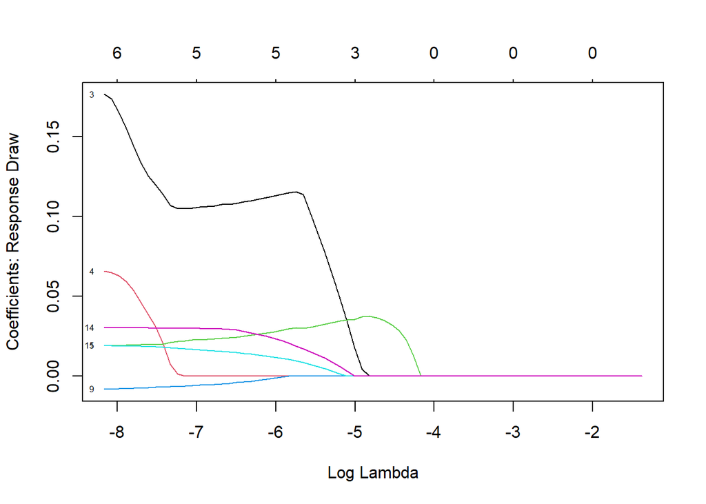

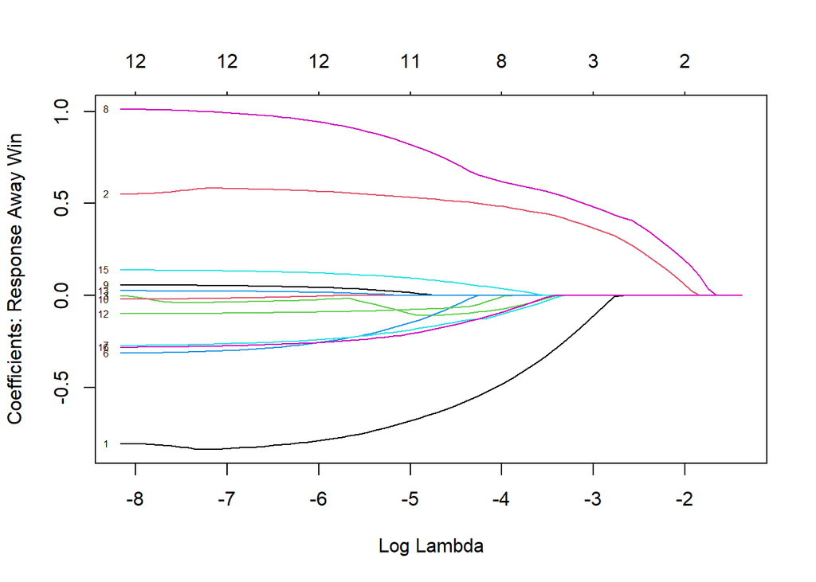

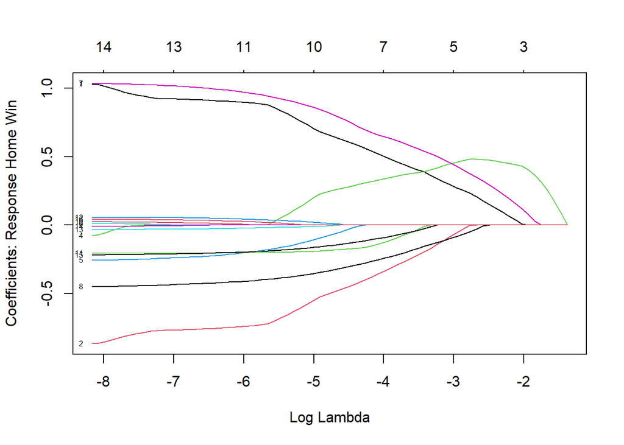

```r
# Prepare the data
x <- model.matrix(FTR ~ HTHG + HTAG + HTR + HS + AS + HST + AST + HF + AF + HC + AC + HY + AY + HR + AR, data = train_data)[, -1]
y <- train_data$FTR

# Scale predictors
x_scaled <- scale(x)

model_fit.lasso <- glmnet(x_scaled, y, family = "multinomial", alpha = 1)

plot(model_fit.lasso, xvar = "lambda", label = TRUE)
```

We choose lambda using cross validation:

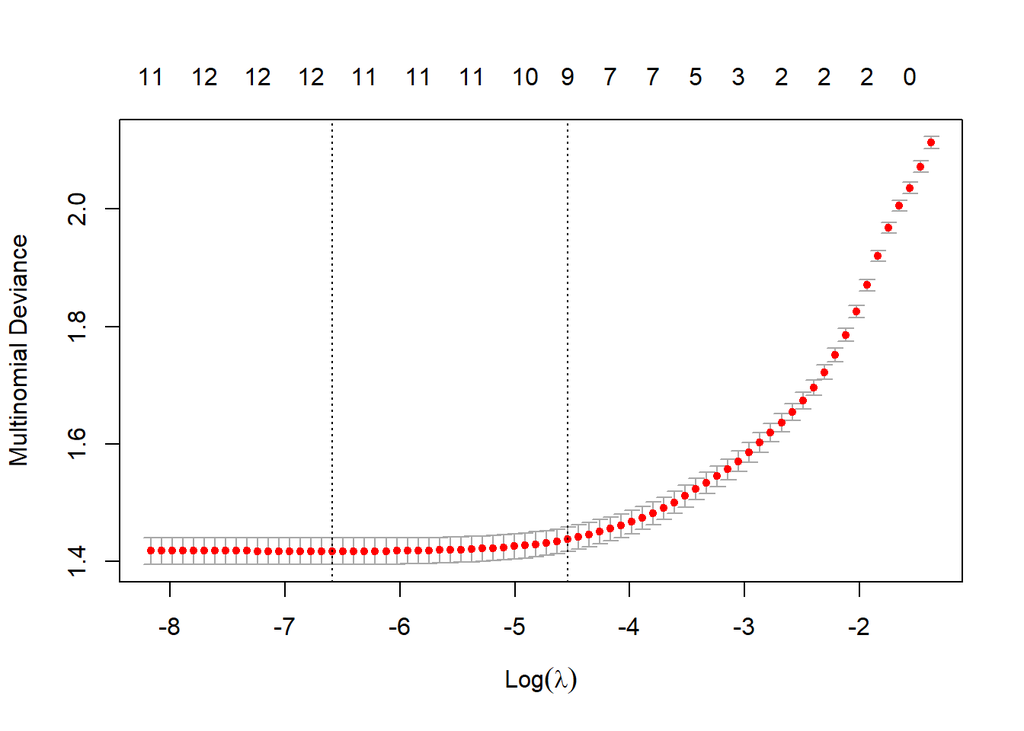

```r
modelcv.lasso <- cv.glmnet(x_scaled, y, alpha = 1, family = "multinomial")

plot(modelcv.lasso)
```

```r
lambda_min <- modelcv.lasso$lambda.min
lambda_min
```

```
## [1] 0.001377978
```

We take as λ value corresponding to one standard error from the minimum of the cross-validated mean square error:

```r
lambda_1se <- modelcv.lasso$lambda.1se
lambda_1se
```

```
## [1] 0.01066918
```

Now visualize again the lasso estimates as a function of the logarithm of λ and add a vertical line corresponding to best.lambda:

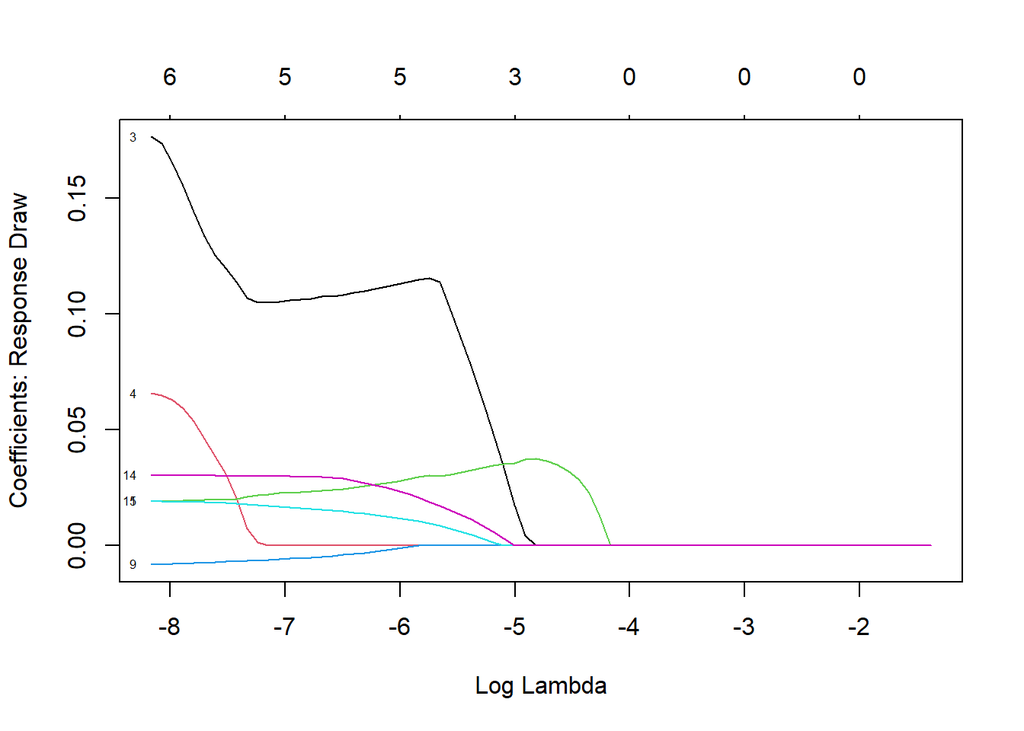

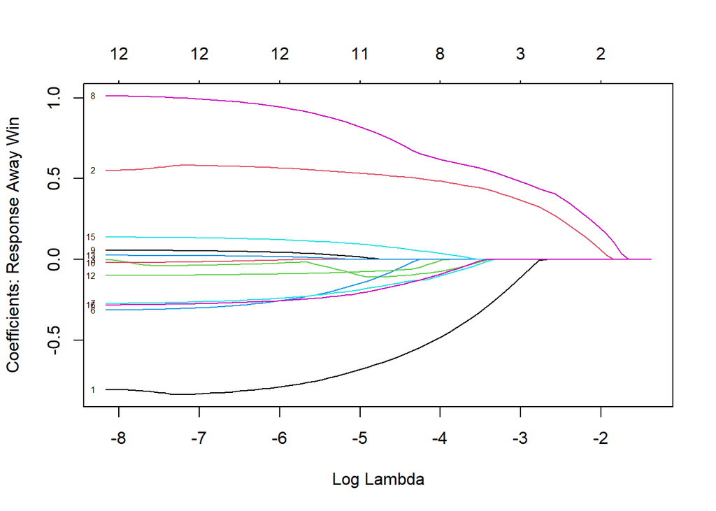

```r
plot(model_fit.lasso, xvar = "lambda", label = TRUE)
```

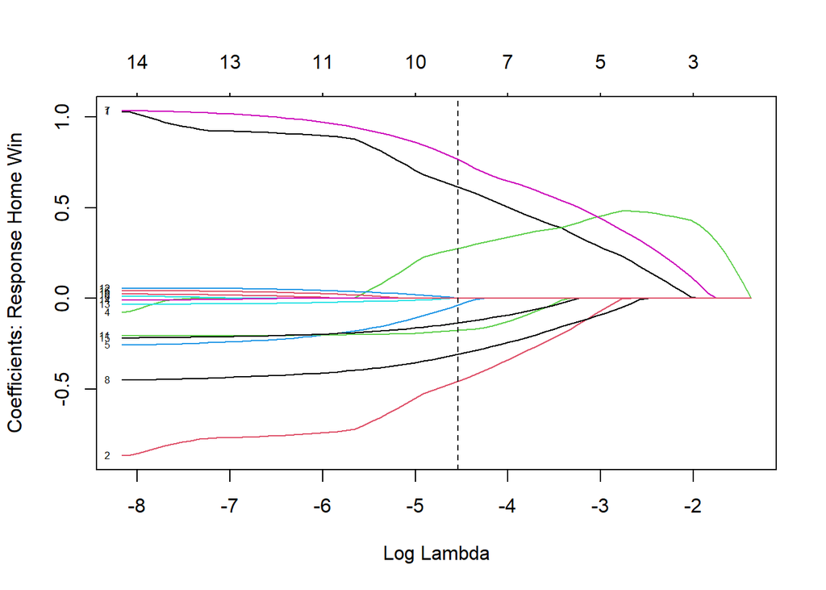

```r
abline(v = log(lambda_1se), lwd = 1.2, lty = "dashed")
```

These are the coefficients:

```r
model_bestlam.lasso.coef <- coef(model_fit.lasso, s = lambda_1se)

nonzero_coefs <- lapply(model_bestlam.lasso.coef, function(coef_matrix) {
  coef_matrix <- as.matrix(coef_matrix)
  coef_matrix[coef_matrix != 0, , drop = FALSE]
})

print(nonzero_coefs)
```

```
## $Draw
##                        1
## (Intercept) -0.002644653
## HS           0.032291755
##
## $`Away Win`
##                       1
## (Intercept) -0.44107261
## HTHG        -0.60311244
## HTAG         0.51513624
## HTRD        -0.10036470
## AS          -0.05903434
## HST         -0.14597029
## AST          0.72533375
## AC          -0.06529600
## HR           0.07338255
## AR          -0.16023640
##
## $`Home Win`
##                       1
## (Intercept)  0.44371726
## HTHG         0.61507858
## HTAG        -0.45719288
## HTRH         0.27510227
## HS          -0.03689189
## HST          0.76720778
## AST         -0.30847374
## HC          -0.17630384
## AC           0.00241848
## HR          -0.13527587
```

Now we apply prediction on the test set.

```r
x_train <- model.matrix(FTR ~ HTHG + HTAG + HTR + HS + AS + HST + AST + HF + AF + HC + AC + HY + AY + HR + AR, data = train_data)[, -1]
x_test <- model.matrix(FTR ~ HTHG + HTAG + HTR + HS + AS + HST + AST + HF + AF + HC + AC + HY + AY + HR + AR, data = test_data)[, -1]

# Align columns between training and test sets
common_columns <- intersect(colnames(x_train), colnames(x_test))
x_test <- x_test[, common_columns, drop = FALSE]
x_train <- x_train[, common_columns, drop = FALSE]

# Rescale training data
x_train_scaled <- scale(x_train)

# Scale the test set using training set scaling parameters
x_test_scaled <- scale(x_test,
                       center = attr(x_train_scaled, "scaled:center"),
                       scale = attr(x_train_scaled, "scaled:scale"))

# Fit LASSO regression on the training set
model_fit.lasso <- glmnet(x_train_scaled, train_data$FTR,
                          family = "multinomial", alpha = 1)

# Perform cross-validation to select lambda
modelcv.lasso <- cv.glmnet(x_train_scaled, train_data$FTR,
                           family = "multinomial", alpha = 1)

# Get the best lambda (lambda.1se)
model_bestlam.lasso <- modelcv.lasso$lambda.1se

# Predict probabilities for the test set
pred_prob_lasso <- predict(model_fit.lasso,
                           newx = x_test_scaled,
                           s = model_bestlam.lasso,
                           type = "response")

# Predict class labels for the test set
pred_class_lasso <- predict(model_fit.lasso,
                            newx = x_test_scaled,
                            s = model_bestlam.lasso,
                            type = "class")

# Convert predictions to factors with the same levels as the test response variable
pred_class_lasso <- factor(pred_class_lasso, levels = levels(test_data$FTR))
```

Now, let’s see the confusion matrix.

```r
conf_matrix_lasso <- confusionMatrix(pred_class_lasso, test_data$FTR)

print(conf_matrix_lasso)
```

```
## Confusion Matrix and Statistics
##
##           Reference
## Prediction Away Win Draw Home Win
##   Away Win      308   91       49
##   Draw           73  128       73
##   Home Win       66  177      630
##
## Overall Statistics
##
##                Accuracy : 0.6683
##                  95% CI : (0.6446, 0.6914)
##     No Information Rate : 0.4715
##     P-Value [Acc > NIR] : < 2.2e-16
##
##                   Kappa : 0.4656
##
##  Mcnemar's Test P-Value : 2.404e-10
##
## Statistics by Class:
##
##                      Class: Away Win Class: Draw Class: Home Win
## Sensitivity                   0.6890     0.32323          0.8378
## Specificity                   0.8780     0.87823          0.7117
## Pos Pred Value                0.6875     0.46715          0.7216
## Neg Pred Value                0.8788     0.79712          0.8310
## Prevalence                    0.2803     0.24828          0.4715
## Detection Rate                0.1931     0.08025          0.3950
## Detection Prevalence          0.2809     0.17179          0.5473
## Balanced Accuracy             0.7835     0.60073          0.7748
```

```r
if (!is.data.frame(pred_prob_lasso)) {
  pred_prob_lasso <- as.data.frame(pred_prob_lasso)
}
```

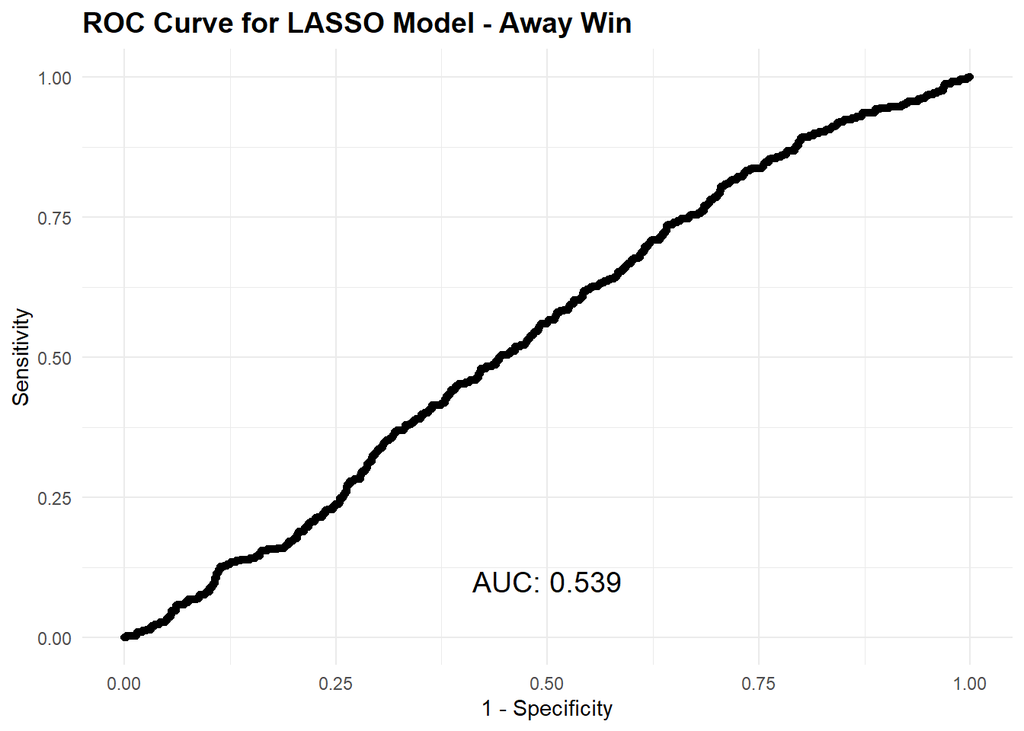

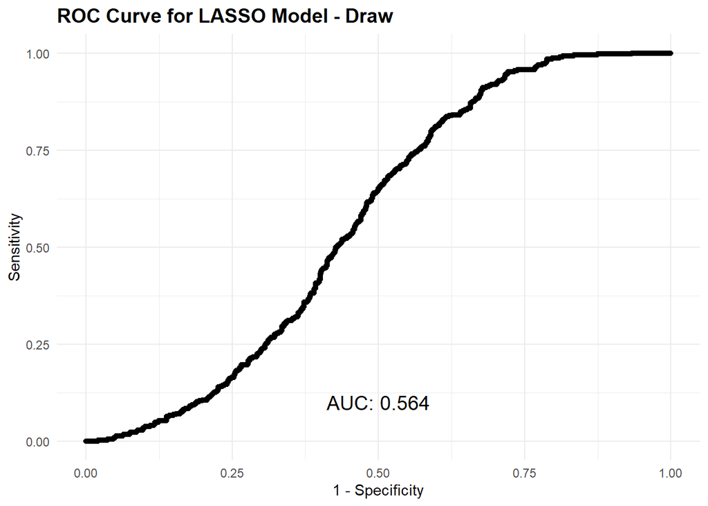

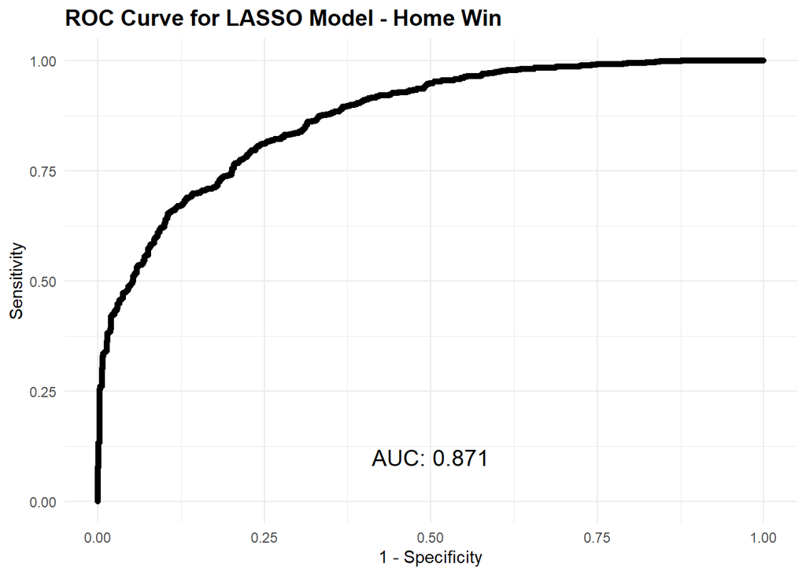

```r
colnames(pred_prob_lasso) <- levels(test_data$FTR)

test_labels <- model.matrix(~ test_data$FTR - 1)
colnames(test_labels) <- levels(test_data$FTR)

plot_roc(test_data, pred_prob_lasso, "LASSO Model")
```

```r
specificity_awaywin_lasso <- conf_matrix_lasso$byClass["Class: Away Win", "Specificity"]
sensitivity_awaywin_lasso <- conf_matrix_lasso$byClass["Class: Away Win", "Sensitivity"]

specificity_draw_lasso <- conf_matrix_lasso$byClass["Class: Draw", "Specificity"]
sensitivity_draw_lasso <- conf_matrix_lasso$byClass["Class: Draw", "Sensitivity"]

specificity_homewin_lasso <- conf_matrix_lasso$byClass["Class: Home Win", "Specificity"]
sensitivity_homewin_lasso <- conf_matrix_lasso$byClass["Class: Home Win", "Sensitivity"]

accuracy_lasso <- conf_matrix_lasso$overall["Accuracy"]

metrics_lasso <- data.frame(
  Model = rep("LASSO Model", 3),
  Class = c("Away Win", "Draw", "Home Win"),
  Accuracy = c(accuracy_lasso, accuracy_lasso, accuracy_lasso),  # Assuming accuracy is the same for all classes
  Sensitivity = c(sensitivity_awaywin_lasso, sensitivity_draw_lasso, sensitivity_homewin_lasso),
  Specificity = c(specificity_awaywin_lasso, specificity_draw_lasso, specificity_homewin_lasso),
  stringsAsFactors = FALSE  # Ensure strings are not converted to factors
)

comparison_df <- rbind(
  comparison_df,
  metrics_lasso
)

print(comparison_df)
```

```
##                        Model    Class  Accuracy Sensitivity Specificity
## 1                 Full Model Away Win 0.7299896   0.7885189   0.7148773
## 2                 Full Model     Draw 0.7289446   0.8058413   0.6985173
## 3                 Full Model Home Win 0.7433647   0.7705527   0.7412823
## 4     Full Interaction Model Away Win 0.7356322   0.7924588   0.7180400
## 5     Full Interaction Model     Draw 0.7299896   0.7885189   0.7148773
## 6     Full Interaction Model Home Win 0.7289446   0.8058413   0.6985173
## 7              Cleaned Model Away Win 0.7433647   0.7705527   0.7412823
## 8              Cleaned Model     Draw 0.7356322   0.7924588   0.7180400
## 9              Cleaned Model Home Win 0.7299896   0.7885189   0.7148773
## 10 Cleaned Interaction Model Away Win 0.7289446   0.8058413   0.6985173
## 11 Cleaned Interaction Model     Draw 0.7433647   0.7705527   0.7412823
## 12 Cleaned Interaction Model Home Win 0.7356322   0.7924588   0.7180400
## 13            Stepwise Model Away Win 0.6677116   0.6957494   0.8736934
## 14            Stepwise Model     Draw 0.6677116   0.3333333   0.8723937
## 15            Stepwise Model Home Win 0.6677116   0.8271277   0.7247924
## 16               LASSO Model Away Win 0.6683386   0.6890380   0.8780488
## 17               LASSO Model     Draw 0.6683386   0.3232323   0.8782319
## 18               LASSO Model Home Win 0.6683386   0.8377660   0.7117438
```

### Ridge logistic regression

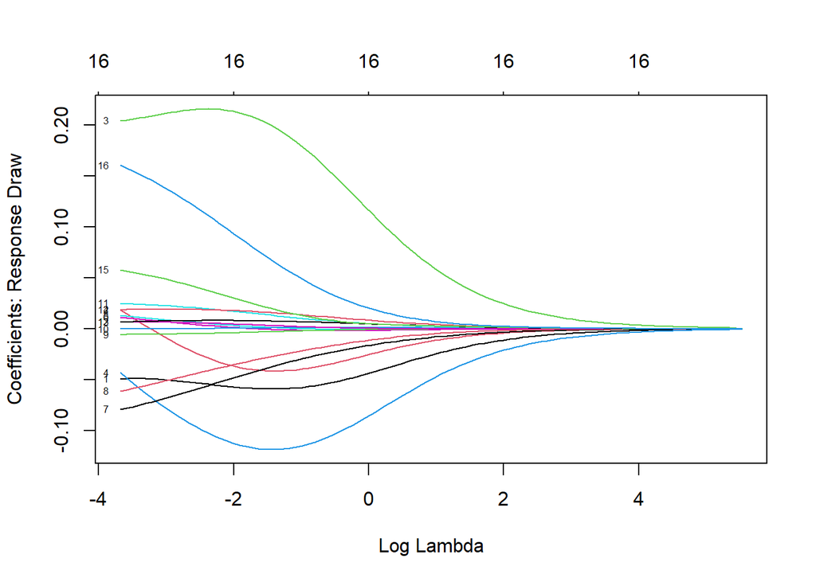

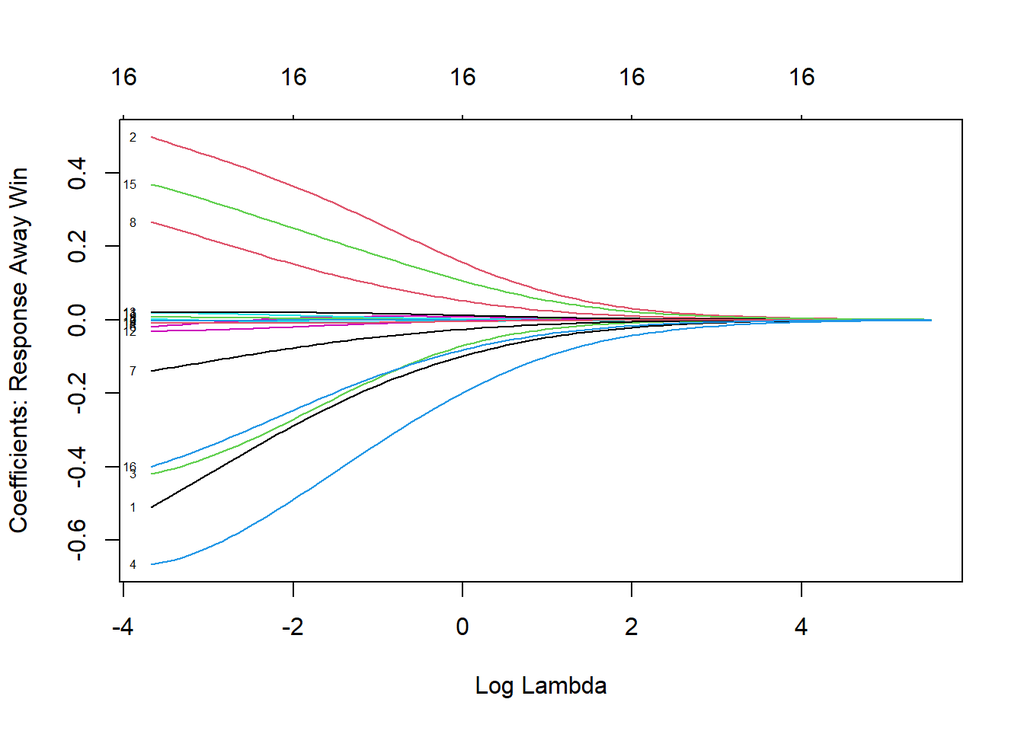

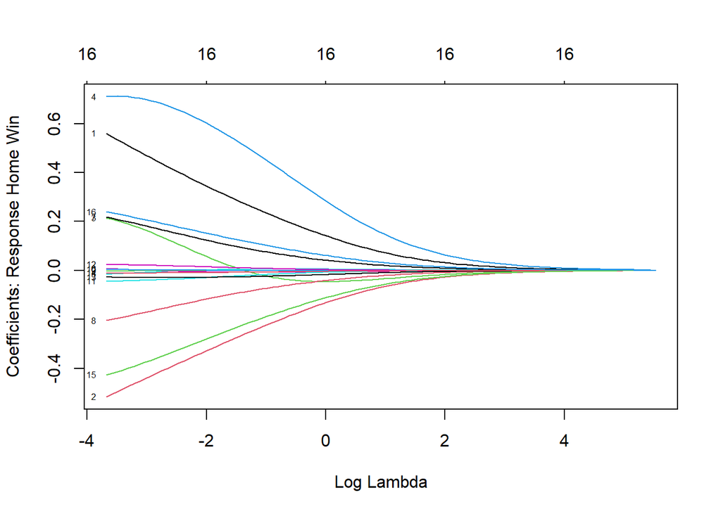

```r
x <- model.matrix(FTR ~ HTHG + HTAG + HTR + HS + AS + HST + AST + HF + AF + HC + AC + HY + AY + HR + AR, data = train_data)[, -1]

y <- train_data$FTR

model_fit.ridge <- glmnet(
  x,
  y,
  family = "multinomial",
  alpha = 0
)

plot(model_fit.ridge, xvar = "lambda", label = TRUE)
```

Choose the best value of lambda via cross-validation.

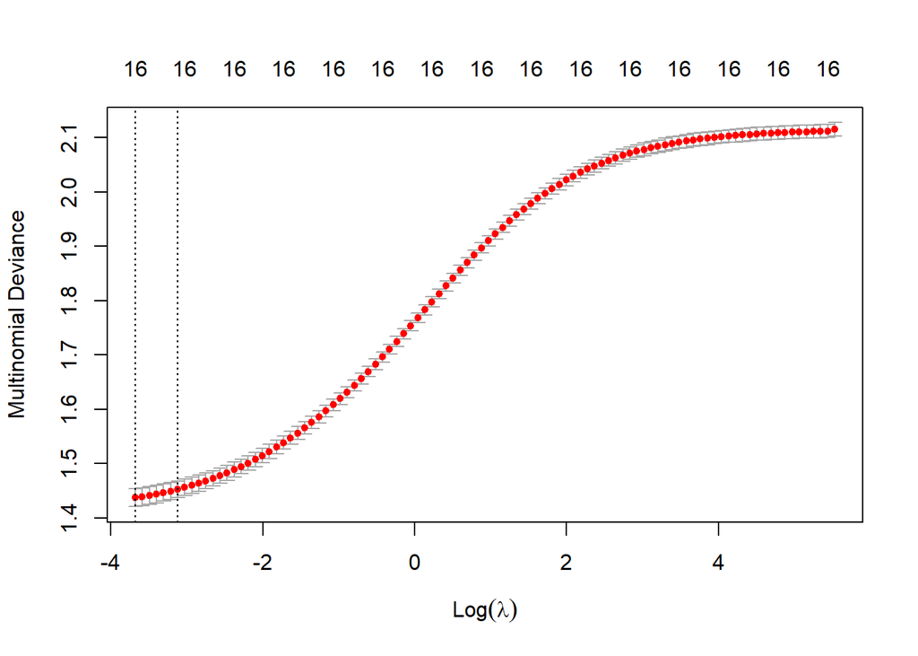

```r
modelcv.ridge <- cv.glmnet(
  x,
  y,
  alpha = 0,
  family = "multinomial"
)

plot(modelcv.ridge)
```

The value of λ that minimizes the ridge cross-validated mean square error is:

```r
modelcv.ridge$lambda.min
```

```
## [1] 0.02522716
```

However, we select the simplest model whose λ value is within one standard error from the minimum of the cross-validated mean square error:

```r
modelcv_bestlam.ridge <- modelcv.ridge$lambda.1se
modelcv_bestlam.ridge
```

```
## [1] 0.04408518
```

Now visualize again the ridge estimates as a function of the logarithm of λ and add a vertical line corresponding to best.lambda:

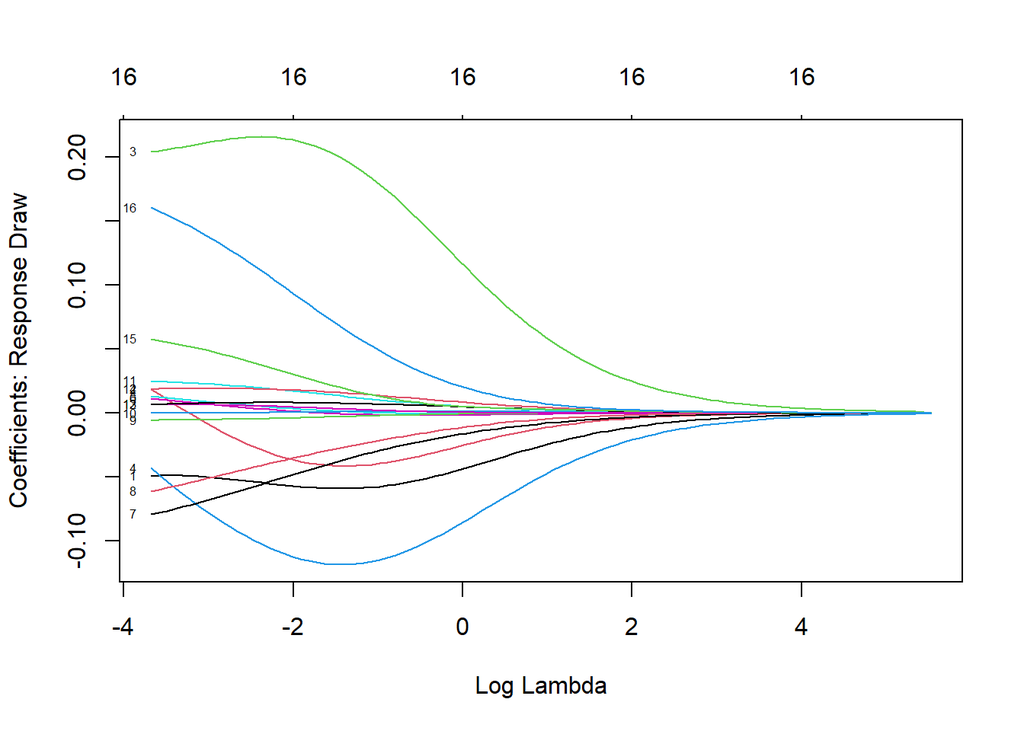

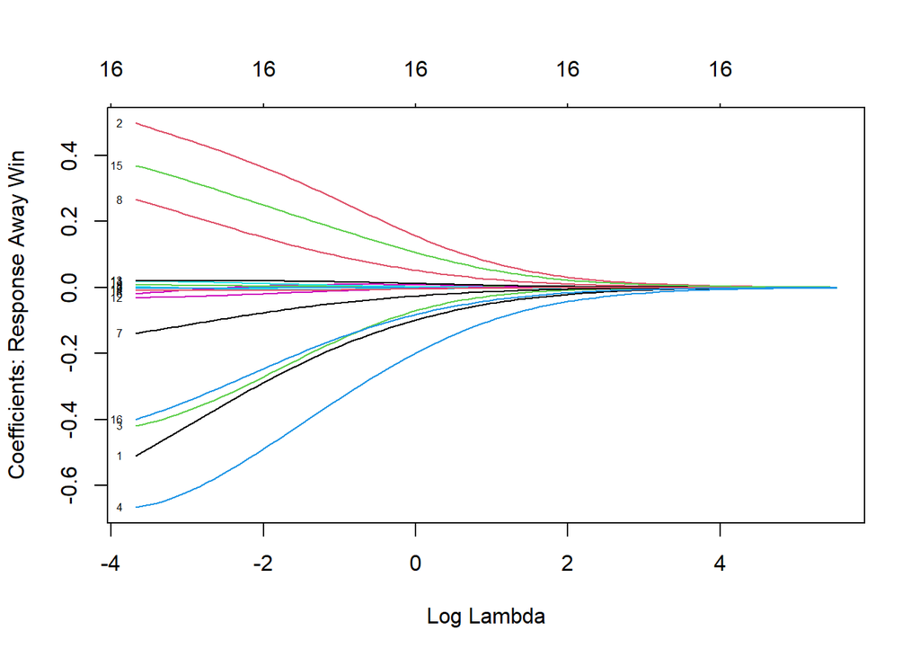

```r
plot(model_fit.ridge, xvar = "lambda", label = TRUE)
```

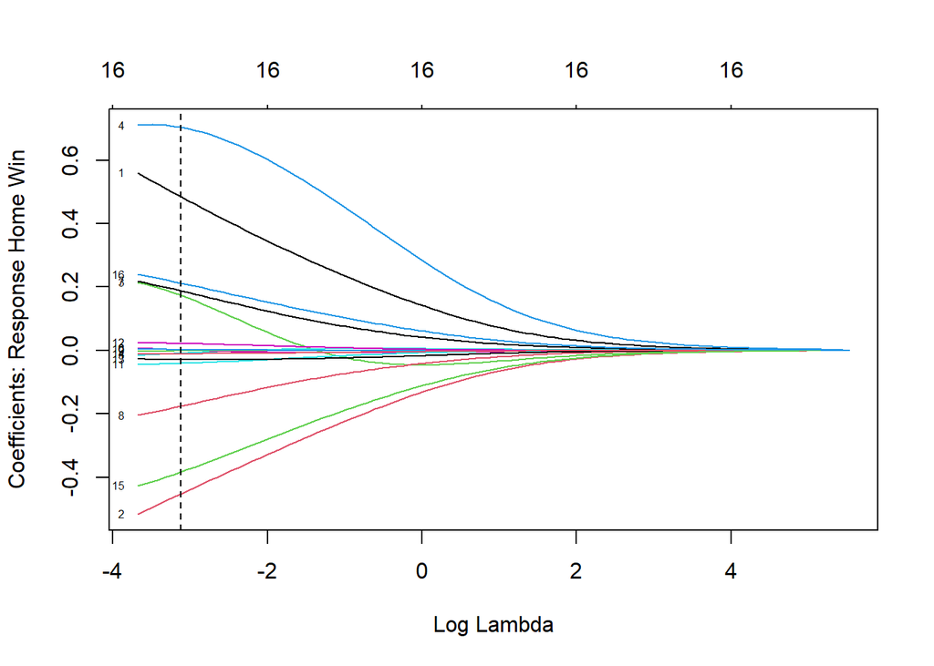

```r
abline(v = log(modelcv_bestlam.ridge), lwd = 1.2, lty = "dashed")
```

These are the coefficients:

```r
model_bestlam.ridge.coef <- coef(model_fit.ridge, s = lambda_1se)

nonzero_coefs <- lapply(model_bestlam.ridge.coef, function(coef_matrix) {
  coef_matrix <- as.matrix(coef_matrix)
  coef_matrix[coef_matrix != 0, , drop = FALSE]
})

print(nonzero_coefs)
```

```
## $Draw
##                         1
## (Intercept)  0.0843787019
## HTHG        -0.0493265240
## HTAG         0.0186383380
## HTRD         0.2041790630
## HTRH        -0.0431150297
## HS           0.0126886532
## AS           0.0116025023
## HST         -0.0792900499
## AST         -0.0612855667
## HF          -0.0056878239
## AF          -0.0002952838
## HC           0.0248458262
## AC           0.0066605206
## HY           0.0065749227
## AY           0.0186777294
## HR           0.0579045583
## AR           0.1605691698
##
## $`Away Win`
##                        1
## (Intercept) -0.132553952
## HTHG        -0.509995621
## HTAG         0.498800006
## HTRD        -0.419054207
## HTRH        -0.666692781
## HS           0.002271471
## AS          -0.018465324
## HST         -0.138730701
## AST          0.266387952
## HF           0.007738084
## AF          -0.003177073
## HC           0.019551574
## AC          -0.031103803
## HY           0.021083414
## AY          -0.007527175
## HR           0.369835010
## AR          -0.400096603
##
## $`Home Win`
##                        1
## (Intercept)  0.048175250
## HTHG         0.559322145
## HTAG        -0.517438344
## HTRD         0.214875145
## HTRH         0.709807810
## HS          -0.014960124
## AS           0.006862822
## HST          0.218020751
## AST         -0.205102385
## HF          -0.002050260
## AF           0.003472357
## HC          -0.044397400
## AC           0.024443282
## HY          -0.027658337
## AY          -0.011150554
## HR          -0.427739569
## AR           0.239527433
```

We make the prediction on the test set.

```r
x_train <- model.matrix(FTR ~ HTHG + HTAG + HTR + HS + AS + HST + AST + HF + AF + HC + AC + HY + AY + HR + AR, data = train_data)[, -1]
x_train_scaled <- scale(x_train)

x_test <- model.matrix(FTR ~ HTHG + HTAG + HTR + HS + AS + HST + AST + HF + AF + HC + AC + HY + AY + HR + AR, data = test_data)[, -1]

common_columns <- intersect(colnames(x_train), colnames(x_test))
x_test <- x_test[, common_columns, drop = FALSE]
x_train <- x_train[, common_columns, drop = FALSE]

x_train_scaled <- scale(x_train)

x_test_scaled <- scale(x_test,
                       center = attr(x_train_scaled, "scaled:center"),
                       scale = attr(x_train_scaled, "scaled:scale"))

# Fit Ridge regression on the training set
model_fit.ridge <- glmnet(x_train_scaled, train_data$FTR,
                          family = "multinomial", alpha = 0)

# Perform cross-validation to select lambda
modelcv.ridge <- cv.glmnet(x_train_scaled, train_data$FTR,
                           family = "multinomial", alpha = 0)

# Get the best lambda (lambda.1se)
model_bestlam.ridge <- modelcv.ridge$lambda.1se

pred_class_ridge <- predict(model_fit.ridge, newx = x_test_scaled, s = model_bestlam.ridge, type = "class")

test_data$FTR <- factor(test_data$FTR)
pred_class_ridge <- factor(pred_class_ridge, levels = levels(test_data$FTR))


conf_matrix_ridge <- confusionMatrix(pred_class_ridge, test_data$FTR)

print(conf_matrix_ridge)
```

```
## Confusion Matrix and Statistics
##
##           Reference
## Prediction Away Win Draw Home Win
##   Away Win      309   90       45
##   Draw           72  129       71
##   Home Win       66  177      636
##
## Overall Statistics
##
##                Accuracy : 0.6734
##                  95% CI : (0.6497, 0.6963)
##     No Information Rate : 0.4715
##     P-Value [Acc > NIR] : < 2.2e-16
##
##                   Kappa : 0.473
##
##  Mcnemar's Test P-Value : 4.265e-11
##
## Statistics by Class:
##
##                      Class: Away Win Class: Draw Class: Home Win
## Sensitivity                   0.6913     0.32576          0.8457
## Specificity                   0.8824     0.88073          0.7117
## Pos Pred Value                0.6959     0.47426          0.7235
## Neg Pred Value                0.8801     0.79819          0.8380
## Prevalence                    0.2803     0.24828          0.4715
## Detection Rate                0.1937     0.08088          0.3987
## Detection Prevalence          0.2784     0.17053          0.5511
## Balanced Accuracy             0.7868     0.60325          0.7787
```

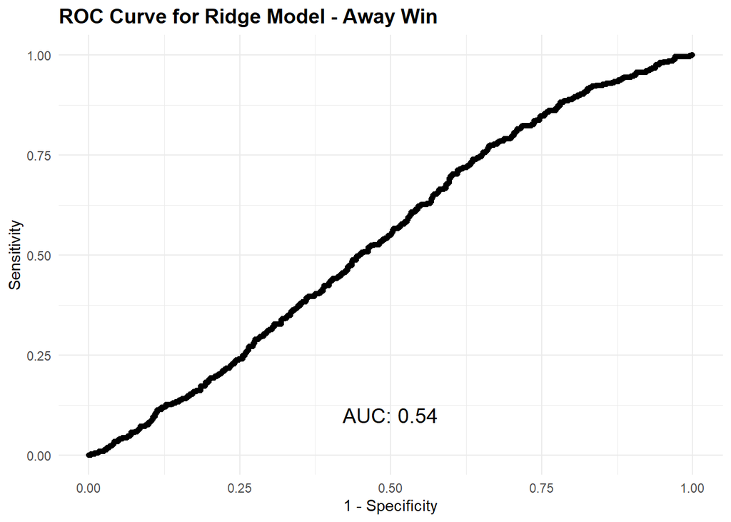

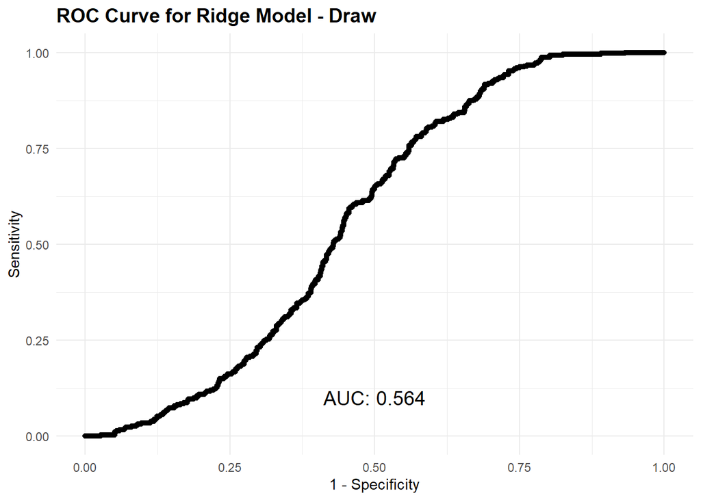

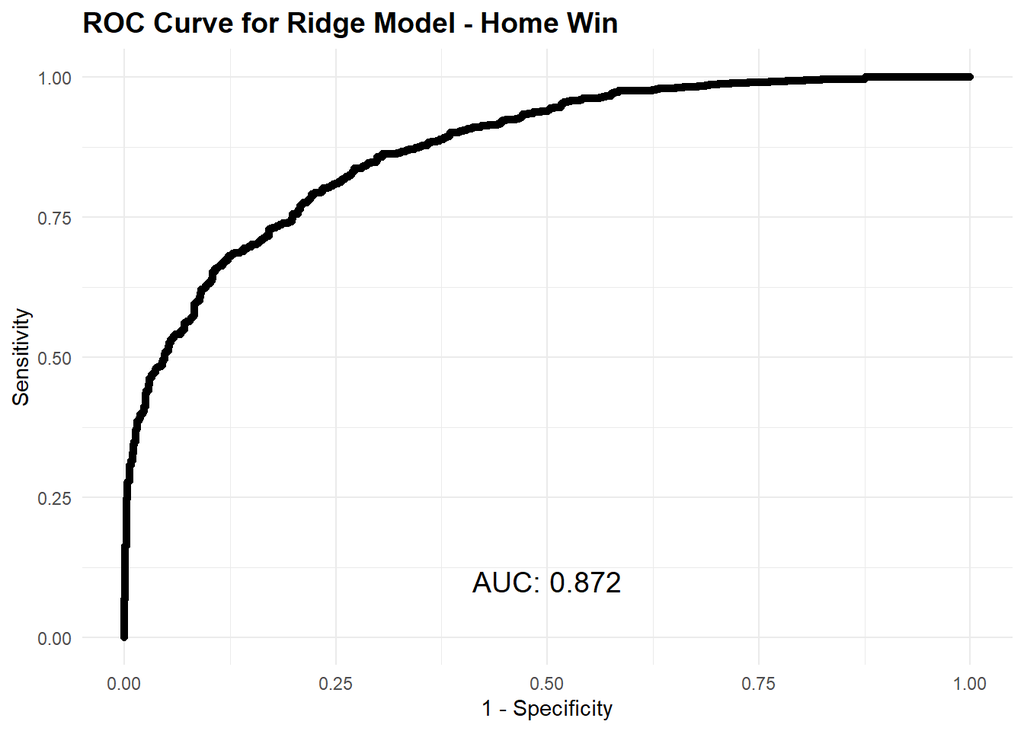

```r
pred_prob_ridge <- predict(model_fit.ridge,
                           newx = x_test_scaled,
                           s = model_bestlam.ridge,
                           type = "response")

pred_prob_ridge <- matrix(pred_prob_ridge, ncol = length(levels(test_data$FTR)))

colnames(pred_prob_ridge) <- levels(test_data$FTR)

test_labels <- model.matrix(~ test_data$FTR - 1)
colnames(test_labels) <- levels(test_data$FTR)

plot_roc(test_data, pred_prob_ridge, "Ridge Model")
```

```r
specificity_awaywin_ridge <- conf_matrix_ridge$byClass["Class: Away Win", "Specificity"]
sensitivity_awaywin_ridge <- conf_matrix_ridge$byClass["Class: Away Win", "Sensitivity"]

specificity_draw_ridge <- conf_matrix_ridge$byClass["Class: Draw", "Specificity"]
sensitivity_draw_ridge <- conf_matrix_ridge$byClass["Class: Draw", "Sensitivity"]

specificity_homewin_ridge <- conf_matrix_ridge$byClass["Class: Home Win", "Specificity"]
sensitivity_homewin_ridge <- conf_matrix_ridge$byClass["Class: Home Win", "Sensitivity"]

accuracy_ridge <- conf_matrix_ridge$overall["Accuracy"]

metrics_ridge <- data.frame(
  Model = rep("Ridge Model", 3),
  Class = c("Away Win", "Draw", "Home Win"),
  Accuracy = c(accuracy_ridge, accuracy_ridge, accuracy_ridge),
  Sensitivity = c(sensitivity_awaywin_ridge, sensitivity_draw_ridge, sensitivity_homewin_ridge),
  Specificity = c(specificity_awaywin_ridge, specificity_draw_ridge, specificity_homewin_ridge),
  stringsAsFactors = FALSE
)

comparison_df <- rbind(
  comparison_df,
  metrics_ridge
)

print(comparison_df)
```

```
##                        Model    Class  Accuracy Sensitivity Specificity
## 1                 Full Model Away Win 0.7299896   0.7885189   0.7148773
## 2                 Full Model     Draw 0.7289446   0.8058413   0.6985173
## 3                 Full Model Home Win 0.7433647   0.7705527   0.7412823
## 4     Full Interaction Model Away Win 0.7356322   0.7924588   0.7180400
## 5     Full Interaction Model     Draw 0.7299896   0.7885189   0.7148773
## 6     Full Interaction Model Home Win 0.7289446   0.8058413   0.6985173
## 7              Cleaned Model Away Win 0.7433647   0.7705527   0.7412823
## 8              Cleaned Model     Draw 0.7356322   0.7924588   0.7180400
## 9              Cleaned Model Home Win 0.7299896   0.7885189   0.7148773
## 10 Cleaned Interaction Model Away Win 0.7289446   0.8058413   0.6985173
## 11 Cleaned Interaction Model     Draw 0.7433647   0.7705527   0.7412823
## 12 Cleaned Interaction Model Home Win 0.7356322   0.7924588   0.7180400
## 13            Stepwise Model Away Win 0.6677116   0.6957494   0.8736934
## 14            Stepwise Model     Draw 0.6677116   0.3333333   0.8723937
## 15            Stepwise Model Home Win 0.6677116   0.8271277   0.7247924
## 16               LASSO Model Away Win 0.6683386   0.6890380   0.8780488
## 17               LASSO Model     Draw 0.6683386   0.3232323   0.8782319
## 18               LASSO Model Home Win 0.6683386   0.8377660   0.7117438
## 19               Ridge Model Away Win 0.6733542   0.6912752   0.8824042
## 20               Ridge Model     Draw 0.6733542   0.3257576   0.8807339
## 21               Ridge Model Home Win 0.6733542   0.8457447   0.7117438
```

### Linear Discriminant Analysis

Now we are going to deal with LDA or Linear Discriminant Analysis. For this type of Generative Model we decide to again use the full model.

```r
x_train <- model.matrix(FTR ~ HTHG + HTAG + HTR + HS + AS + HST + AST + HF + AF + HC + AC + HY + AY + HR + AR, data = train_data)[, -1]
x_train_scaled <- scale(x_train)

x_test <- model.matrix(FTR ~ ., data = test_data)[, -1]

common_columns <- intersect(colnames(x_train), colnames(x_test))
x_test <- x_test[, common_columns, drop = FALSE]
x_train <- x_train[, common_columns, drop = FALSE]

x_train_scaled <- scale(x_train)

x_test_scaled <- scale(x_test,
                       center = attr(x_train_scaled, "scaled:center"),
                       scale = attr(x_train_scaled, "scaled:scale"))

lda_model <- lda(FTR ~ ., data = data.frame(x_train_scaled, FTR = train_data$FTR))
```

```r
pred_class_lda <- predict(lda_model, newdata = data.frame(x_test_scaled))$class

test_data$FTR <- factor(test_data$FTR)
pred_class_lda <- factor(pred_class_lda, levels = levels(test_data$FTR))
```

```r
conf_matrix_lda <- confusionMatrix(pred_class_lda, test_data$FTR)

print(conf_matrix_lda)
```

```
## Confusion Matrix and Statistics
##
##           Reference
## Prediction Away Win Draw Home Win
##   Away Win      284   77       51
##   Draw          113  187      124
##   Home Win       50  132      577
##
## Overall Statistics
##
##                Accuracy : 0.6571
##                  95% CI : (0.6332, 0.6804)
##     No Information Rate : 0.4715
##     P-Value [Acc > NIR] : < 2e-16
##
##                   Kappa : 0.4618
##
##  Mcnemar's Test P-Value : 0.06936
##
## Statistics by Class:
##
##                      Class: Away Win Class: Draw Class: Home Win
## Sensitivity                   0.6353      0.4722          0.7673
## Specificity                   0.8885      0.8023          0.7841
## Pos Pred Value                0.6893      0.4410          0.7602
## Neg Pred Value                0.8622      0.8215          0.7907
## Prevalence                    0.2803      0.2483          0.4715
## Detection Rate                0.1781      0.1172          0.3618
## Detection Prevalence          0.2583      0.2658          0.4759
## Balanced Accuracy             0.7619      0.6373          0.7757
```

```r
specificity_awaywin_lda <- conf_matrix_lda$byClass["Class: Away Win", "Specificity"]
sensitivity_awaywin_lda <- conf_matrix_lda$byClass["Class: Away Win", "Sensitivity"]

specificity_draw_lda <- conf_matrix_lda$byClass["Class: Draw", "Specificity"]
sensitivity_draw_lda <- conf_matrix_lda$byClass["Class: Draw", "Sensitivity"]

specificity_homewin_lda <- conf_matrix_lda$byClass["Class: Home Win", "Specificity"]
sensitivity_homewin_lda <- conf_matrix_lda$byClass["Class: Home Win", "Sensitivity"]

accuracy_lda <- conf_matrix_lda$overall["Accuracy"]

metrics_lda <- data.frame(
  Model = rep("LDA Model", 3),
  Class = c("Away Win", "Draw", "Home Win"),
  Accuracy = c(accuracy_lda, accuracy_lda, accuracy_lda),
  Sensitivity = c(sensitivity_awaywin_lda, sensitivity_draw_lda, sensitivity_homewin_lda),
  Specificity = c(specificity_awaywin_lda, specificity_draw_lda, specificity_homewin_lda),
  stringsAsFactors = FALSE
)

comparison_df <- rbind(
  comparison_df,
  metrics_lda
)

print(comparison_df)
```

```
##                        Model    Class  Accuracy Sensitivity Specificity
## 1                 Full Model Away Win 0.7299896   0.7885189   0.7148773
## 2                 Full Model     Draw 0.7289446   0.8058413   0.6985173
## 3                 Full Model Home Win 0.7433647   0.7705527   0.7412823
## 4     Full Interaction Model Away Win 0.7356322   0.7924588   0.7180400
## 5     Full Interaction Model     Draw 0.7299896   0.7885189   0.7148773
## 6     Full Interaction Model Home Win 0.7289446   0.8058413   0.6985173
## 7              Cleaned Model Away Win 0.7433647   0.7705527   0.7412823
## 8              Cleaned Model     Draw 0.7356322   0.7924588   0.7180400
## 9              Cleaned Model Home Win 0.7299896   0.7885189   0.7148773
## 10 Cleaned Interaction Model Away Win 0.7289446   0.8058413   0.6985173
## 11 Cleaned Interaction Model     Draw 0.7433647   0.7705527   0.7412823
## 12 Cleaned Interaction Model Home Win 0.7356322   0.7924588   0.7180400
## 13            Stepwise Model Away Win 0.6677116   0.6957494   0.8736934
## 14            Stepwise Model     Draw 0.6677116   0.3333333   0.8723937
## 15            Stepwise Model Home Win 0.6677116   0.8271277   0.7247924
## 16               LASSO Model Away Win 0.6683386   0.6890380   0.8780488
## 17               LASSO Model     Draw 0.6683386   0.3232323   0.8782319
## 18               LASSO Model Home Win 0.6683386   0.8377660   0.7117438
## 19               Ridge Model Away Win 0.6733542   0.6912752   0.8824042
## 20               Ridge Model     Draw 0.6733542   0.3257576   0.8807339
## 21               Ridge Model Home Win 0.6733542   0.8457447   0.7117438
## 22                 LDA Model Away Win 0.6570533   0.6353468   0.8885017
## 23                 LDA Model     Draw 0.6570533   0.4722222   0.8023353
## 24                 LDA Model Home Win 0.6570533   0.7672872   0.7841044
```

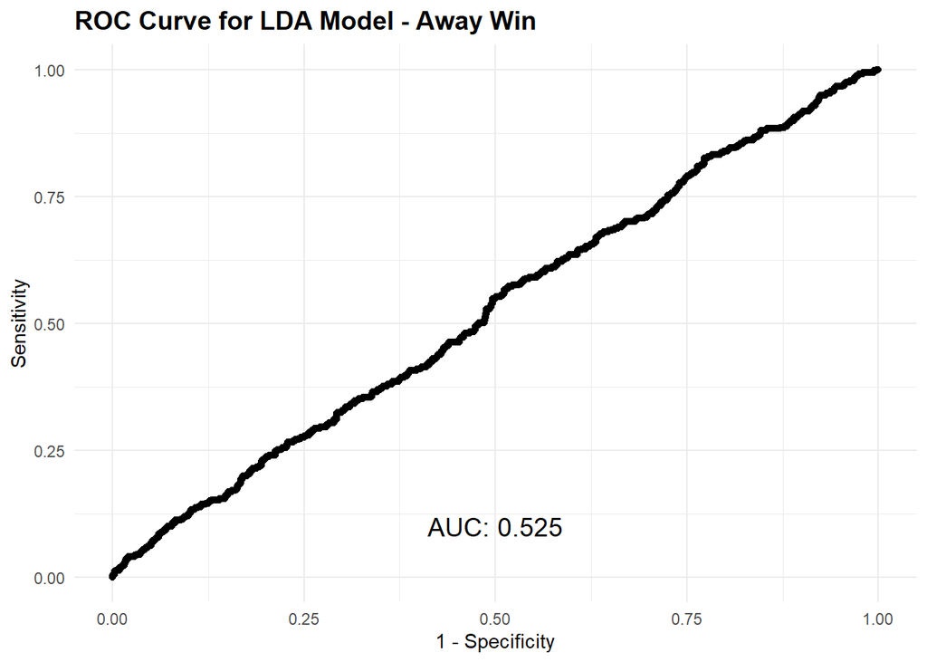

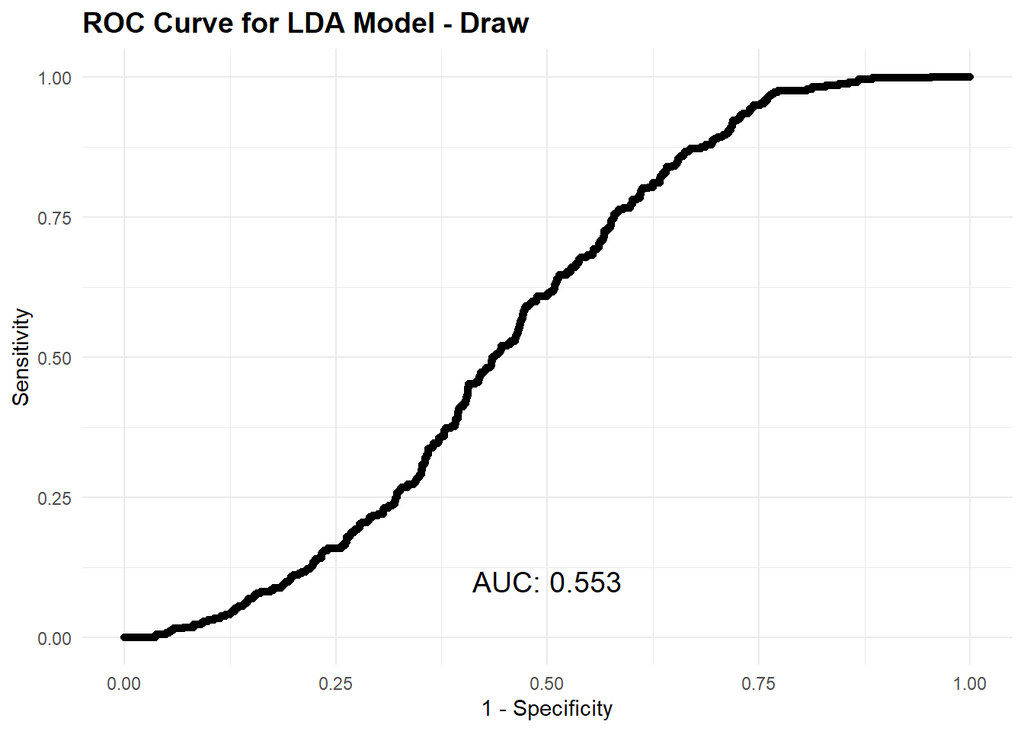

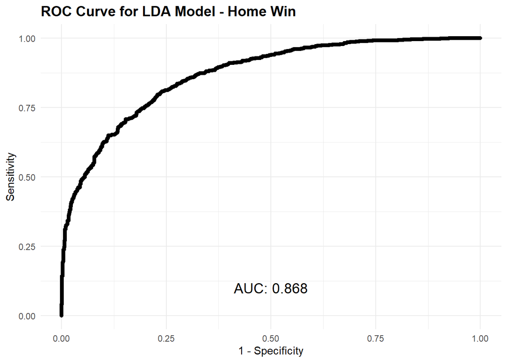

```r
# Get predicted probabilities for LDA model
pred_prob_lda <- predict(lda_model, newdata = data.frame(x_test_scaled))$posterior

# Ensure the column names match the levels of the response variable
colnames(pred_prob_lda) <- levels(test_data$FTR)

# Generate true labels for ROC computation
test_labels <- model.matrix(~ test_data$FTR - 1)
colnames(test_labels) <- levels(test_data$FTR)

plot_roc(test_data, pred_prob_lda, "LDA Model")
```

### Naive Bayes

Continuing with the analysis we try Naive Bayes algorithm.

```r
model_nb <- naiveBayes(FTR ~ HTHG + HTAG + HTR + HS + AS + HST + AST + HF + AF + HC + AC + HY + AY + HR + AR, data = train_data)
model_nb
```

```
##
## Naive Bayes Classifier for Discrete Predictors
##
## Call:
## naiveBayes.default(x = X, y = Y, laplace = laplace)
##
## A-priori probabilities:
## Y
##      Draw  Away Win  Home Win
## 0.2480537 0.2805369 0.4714094
##
## Conditional probabilities:
##           HTHG
## Y               [,1]      [,2]
##   Draw     0.4231602 0.5828391
##   Away Win 0.2593301 0.5073422
##   Home Win 1.0956720 0.9458041
##
##           HTAG
## Y               [,1]      [,2]
##   Draw     0.4339827 0.5988188
##   Away Win 0.9598086 0.8896553
##   Home Win 0.2545558 0.4945363
##
##           HTR
## Y                   A          D          H
##   Draw     0.19155844 0.61796537 0.19047619
##   Away Win 0.55406699 0.37894737 0.06698565
##   Home Win 0.04612756 0.34510251 0.60876993
##
##           HS
## Y              [,1]     [,2]
##   Draw     13.34199 5.289038
##   Away Win 12.73780 4.911687
##   Home Win 14.47665 4.939061
##
##           AS
## Y              [,1]     [,2]
##   Draw     10.50108 4.281660
##   Away Win 12.00000 4.485823
```

[output cut: 46 more lines]

```
##   Draw     2.834416 1.531775
##   Away Win 2.655502 1.604585
##   Home Win 2.666287 1.486587
##
##           HR
## Y                [,1]      [,2]
##   Draw     0.12987013 0.3611940
##   Away Win 0.20669856 0.4499394
##   Home Win 0.06890661 0.2686489
##
##           AR
## Y                [,1]      [,2]
##   Draw     0.16991342 0.4035643
##   Away Win 0.08516746 0.2893713
##   Home Win 0.19874715 0.4476194
```

Prediction for the test set:

```r
# Get predicted probabilities for Naive Bayes model
pred_prob_nb <- predict(model_nb, newdata = test_data, type = "raw")
```

Let’s plot the ROC :

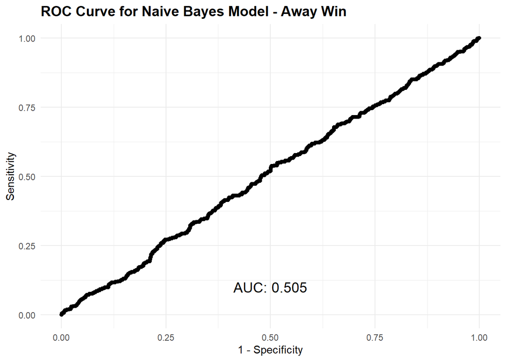

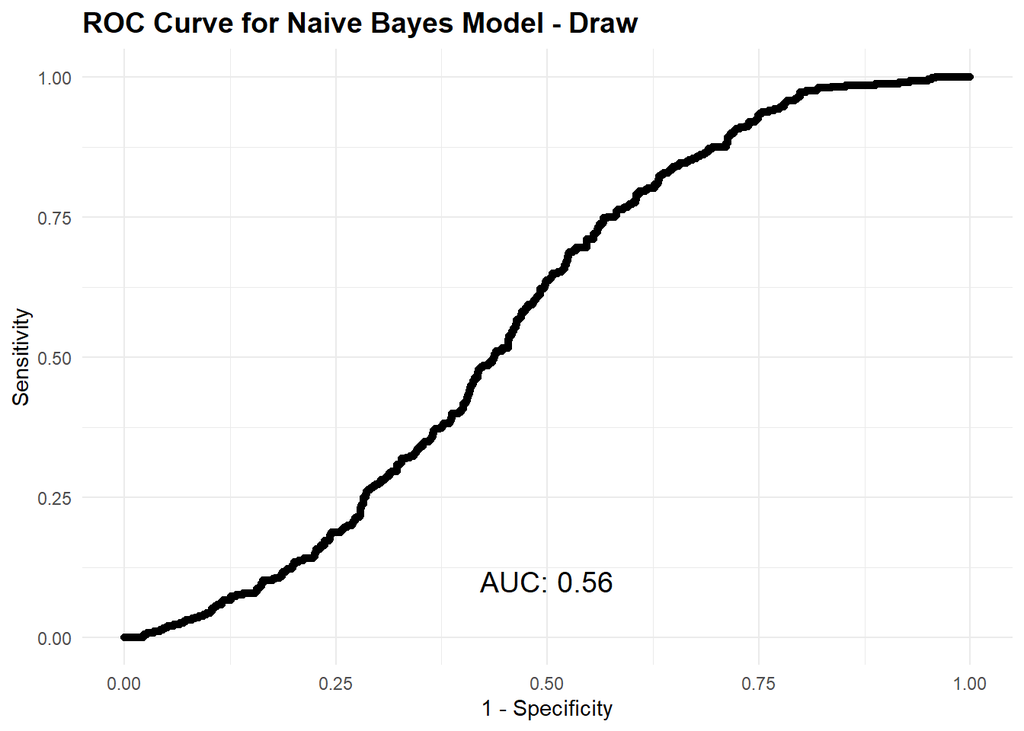

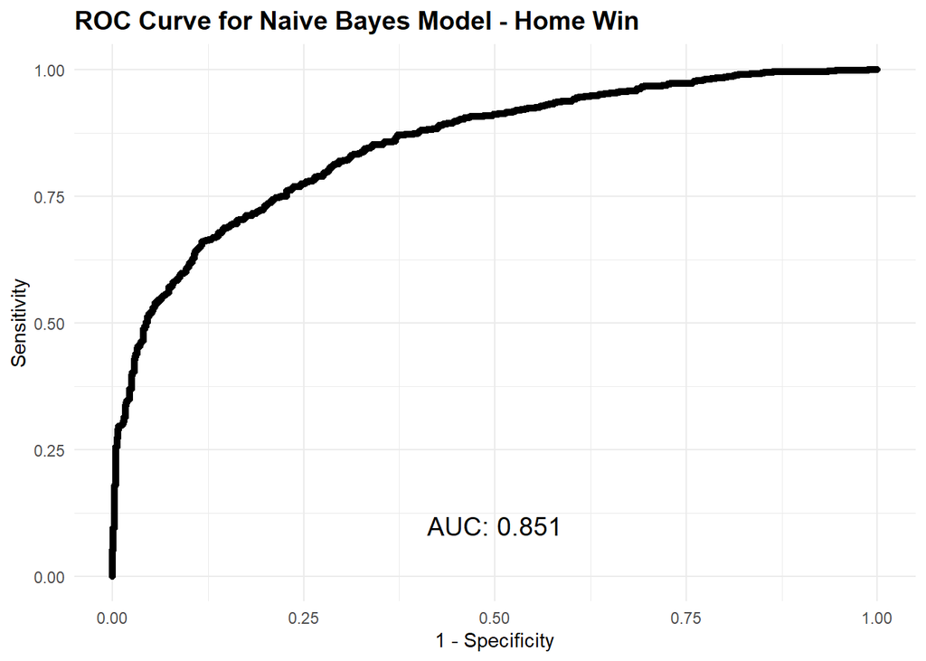

```r
# Ensure the column names match the levels of the response variable
colnames(pred_prob_nb) <- levels(test_data$FTR)

# Generate true labels for ROC computation
test_labels <- model.matrix(~ test_data$FTR - 1)
colnames(test_labels) <- levels(test_data$FTR)

plot_roc(test_data, pred_prob_nb, "Naive Bayes Model")
```

```r
pred_class_nb <- predict(model_nb, newdata = test_data)

test_data$FTR <- factor(test_data$FTR)
pred_class_nb <- factor(pred_class_nb, levels = levels(test_data$FTR))

conf_matrix_nb <- confusionMatrix(pred_class_nb, test_data$FTR)

print(conf_matrix_nb)
```

```
## Confusion Matrix and Statistics
##
##           Reference
## Prediction Away Win Draw Home Win
##   Away Win      286  100       66
##   Draw          115  184      142
##   Home Win       46  112      544
##
## Overall Statistics
##
##                Accuracy : 0.6357
##                  95% CI : (0.6116, 0.6594)
##     No Information Rate : 0.4715
##     P-Value [Acc > NIR] : < 2e-16
##
##                   Kappa : 0.4347
##
##  Mcnemar's Test P-Value : 0.04279
##
## Statistics by Class:
##
##                      Class: Away Win Class: Draw Class: Home Win
## Sensitivity                   0.6398      0.4646          0.7234
## Specificity                   0.8554      0.7857          0.8126
## Pos Pred Value                0.6327      0.4172          0.7749
## Neg Pred Value                0.8591      0.8163          0.7671
## Prevalence                    0.2803      0.2483          0.4715
## Detection Rate                0.1793      0.1154          0.3411
## Detection Prevalence          0.2834      0.2765          0.4401
## Balanced Accuracy             0.7476      0.6252          0.7680
```

```r
specificity_awaywin_nb <- conf_matrix_nb$byClass["Class: Away Win", "Specificity"]
sensitivity_awaywin_nb <- conf_matrix_nb$byClass["Class: Away Win", "Sensitivity"]

specificity_draw_nb <- conf_matrix_nb$byClass["Class: Draw", "Specificity"]
sensitivity_draw_nb <- conf_matrix_nb$byClass["Class: Draw", "Sensitivity"]

specificity_homewin_nb <- conf_matrix_nb$byClass["Class: Home Win", "Specificity"]
sensitivity_homewin_nb <- conf_matrix_nb$byClass["Class: Home Win", "Sensitivity"]

accuracy_nb <- conf_matrix_nb$overall["Accuracy"]

metrics_nb <- data.frame(
  Model = rep("Naive Bayes", 3),
  Class = c("Away Win", "Draw", "Home Win"),
  Accuracy = c(accuracy_nb, accuracy_nb, accuracy_nb),
  Sensitivity = c(sensitivity_awaywin_nb, sensitivity_draw_nb, sensitivity_homewin_nb),
  Specificity = c(specificity_awaywin_nb, specificity_draw_nb, specificity_homewin_nb),
  stringsAsFactors = FALSE
)

comparison_df <- rbind(
  comparison_df,
  metrics_nb
)

print(comparison_df)
```

```
##                        Model    Class  Accuracy Sensitivity Specificity
## 1                 Full Model Away Win 0.7299896   0.7885189   0.7148773
## 2                 Full Model     Draw 0.7289446   0.8058413   0.6985173
## 3                 Full Model Home Win 0.7433647   0.7705527   0.7412823
## 4     Full Interaction Model Away Win 0.7356322   0.7924588   0.7180400
## 5     Full Interaction Model     Draw 0.7299896   0.7885189   0.7148773
## 6     Full Interaction Model Home Win 0.7289446   0.8058413   0.6985173
## 7              Cleaned Model Away Win 0.7433647   0.7705527   0.7412823
## 8              Cleaned Model     Draw 0.7356322   0.7924588   0.7180400
## 9              Cleaned Model Home Win 0.7299896   0.7885189   0.7148773
## 10 Cleaned Interaction Model Away Win 0.7289446   0.8058413   0.6985173
## 11 Cleaned Interaction Model     Draw 0.7433647   0.7705527   0.7412823
## 12 Cleaned Interaction Model Home Win 0.7356322   0.7924588   0.7180400
## 13            Stepwise Model Away Win 0.6677116   0.6957494   0.8736934
## 14            Stepwise Model     Draw 0.6677116   0.3333333   0.8723937
## 15            Stepwise Model Home Win 0.6677116   0.8271277   0.7247924
## 16               LASSO Model Away Win 0.6683386   0.6890380   0.8780488
## 17               LASSO Model     Draw 0.6683386   0.3232323   0.8782319
## 18               LASSO Model Home Win 0.6683386   0.8377660   0.7117438
## 19               Ridge Model Away Win 0.6733542   0.6912752   0.8824042
## 20               Ridge Model     Draw 0.6733542   0.3257576   0.8807339
## 21               Ridge Model Home Win 0.6733542   0.8457447   0.7117438
## 22                 LDA Model Away Win 0.6570533   0.6353468   0.8885017
## 23                 LDA Model     Draw 0.6570533   0.4722222   0.8023353
## 24                 LDA Model Home Win 0.6570533   0.7672872   0.7841044
## 25               Naive Bayes Away Win 0.6357367   0.6398210   0.8554007
## 26               Naive Bayes     Draw 0.6357367   0.4646465   0.7856547
## 27               Naive Bayes Home Win 0.6357367   0.7234043   0.8125741
```

## Conclusion

```r
print(comparison_df)
```

```
##                        Model    Class  Accuracy Sensitivity Specificity
## 1                 Full Model Away Win 0.7299896   0.7885189   0.7148773
## 2                 Full Model     Draw 0.7289446   0.8058413   0.6985173
## 3                 Full Model Home Win 0.7433647   0.7705527   0.7412823
## 4     Full Interaction Model Away Win 0.7356322   0.7924588   0.7180400
## 5     Full Interaction Model     Draw 0.7299896   0.7885189   0.7148773
## 6     Full Interaction Model Home Win 0.7289446   0.8058413   0.6985173
## 7              Cleaned Model Away Win 0.7433647   0.7705527   0.7412823
## 8              Cleaned Model     Draw 0.7356322   0.7924588   0.7180400
## 9              Cleaned Model Home Win 0.7299896   0.7885189   0.7148773
## 10 Cleaned Interaction Model Away Win 0.7289446   0.8058413   0.6985173
## 11 Cleaned Interaction Model     Draw 0.7433647   0.7705527   0.7412823
## 12 Cleaned Interaction Model Home Win 0.7356322   0.7924588   0.7180400
## 13            Stepwise Model Away Win 0.6677116   0.6957494   0.8736934
## 14            Stepwise Model     Draw 0.6677116   0.3333333   0.8723937
## 15            Stepwise Model Home Win 0.6677116   0.8271277   0.7247924
## 16               LASSO Model Away Win 0.6683386   0.6890380   0.8780488
## 17               LASSO Model     Draw 0.6683386   0.3232323   0.8782319
## 18               LASSO Model Home Win 0.6683386   0.8377660   0.7117438
## 19               Ridge Model Away Win 0.6733542   0.6912752   0.8824042
## 20               Ridge Model     Draw 0.6733542   0.3257576   0.8807339
## 21               Ridge Model Home Win 0.6733542   0.8457447   0.7117438
## 22                 LDA Model Away Win 0.6570533   0.6353468   0.8885017
## 23                 LDA Model     Draw 0.6570533   0.4722222   0.8023353
## 24                 LDA Model Home Win 0.6570533   0.7672872   0.7841044
## 25               Naive Bayes Away Win 0.6357367   0.6398210   0.8554007
## 26               Naive Bayes     Draw 0.6357367   0.4646465   0.7856547
## 27               Naive Bayes Home Win 0.6357367   0.7234043   0.8125741
```

Let’s find the best model for all the metrics:

1. Accuracy

```r
best_models_accuracy <- comparison_df %>%
  group_by(Class) %>%
  slice(which.max(Accuracy)) %>%
  ungroup()

print(best_models_accuracy)
```

```
## # A tibble: 3 × 5
##   Model                     Class    Accuracy Sensitivity Specificity
##   <chr>                     <chr>       <dbl>       <dbl>       <dbl>
## 1 Cleaned Model             Away Win    0.743       0.771       0.741
## 2 Cleaned Interaction Model Draw        0.743       0.771       0.741
## 3 Full Model                Home Win    0.743       0.771       0.741
```

The best model in terms of accuracy is the **Cleaned Model** for the class “Away Win,” the **Cleaned Interaction Model** for the class “Draw,” and the **Full Model** for the class “Home Win.”

2. Sensitivity

```r
best_models_sensitivity <- comparison_df %>%
  group_by(Class) %>%
  slice(which.max(Sensitivity)) %>%
  ungroup()

print(best_models_sensitivity)
```

```
## # A tibble: 3 × 5
##   Model                     Class    Accuracy Sensitivity Specificity
##   <chr>                     <chr>       <dbl>       <dbl>       <dbl>
## 1 Cleaned Interaction Model Away Win    0.729       0.806       0.699
## 2 Full Model                Draw        0.729       0.806       0.699
## 3 Ridge Model               Home Win    0.673       0.846       0.712
```

The best model in terms of sensitivity is the **Cleaned Interaction Model** for the class “Away Win,” the **Full Model** for the class “Draw,” and the **Ridge Model** for the class “Home Win.”

3. Specificity

```r
best_models_specificity <- comparison_df %>%
  group_by(Class) %>%
  slice(which.max(Specificity)) %>%
  ungroup()

print(best_models_specificity)
```

```
## # A tibble: 3 × 5
##   Model       Class    Accuracy Sensitivity Specificity
##   <chr>       <chr>       <dbl>       <dbl>       <dbl>
## 1 LDA Model   Away Win    0.657       0.635       0.889
## 2 Ridge Model Draw        0.673       0.326       0.881
## 3 Naive Bayes Home Win    0.636       0.723       0.813
```

The best model in terms of specificity is the **LDA Model** for the class “Away Win,” the **Ridge Model** for the class “Draw,” and the **Naive Bayes** for the class “Home Win.”

One model that performs well across all conditions (Away Win, Draw, and Home Win) and balances accuracy, sensitivity, and specificity, the best choice would be the **Cleaned Model**. It provides good accuracy (74.34% for Away Win, 73.56% for Draw, and 72.99% for Home Win), good specificity (74.13% for Away Win, 71.81% for Draw, and 71.43% for Home Win), and good sensitivity (77.05% for Away Win, 79.25% for Draw, and 78.85% for Home Win).

While no single model dominates all metrics in each case, the Cleaned Model offers a strong balance across all three classes, making it a reliable choice. So, choosing **Cleaned Model** for predicting the final results for the matches of the 2023/2024 season.

# Saving the Model

```r
# Save the model object to a file
saveRDS(multinom_model.clean, "./model/model_file.rds")
```